# Gaze analysis

Maria Polychronidou

30/3/2022

Preprocessing in Data Viewer software. I merged nearby fixations that had duration less than 100 ms (Fixation Duration Threshold) and were within 1.5° (Fixation Merging Amplitude Threshold) of the target fixation. I also removed the fixations that were immediately before and after blinks (Duration to exclude before and after blink saccades: 100 ms).

# 1 Load packages

```r
library(lmerTest)
library(lme4)
library(car)
library(visreg)
library(boot)
library(multcomp)
library(emmeans)
library(tidyverse)
```

```r
library(dplyr)
library(readxl)

# useful plotting functions:
if (!file.exists("myFunctions.R")) {
    download.file("http://www.let.rug.nl/wieling/Statistics/Mixed-Effects/lab/myFunctions.R",
        "myFunctions.R")
}

source("myFunctions.R")
```

# 2 Load data

```r
library(readr)
Polym001 <- read_delim("Fixation report with filters (merge fixations and blink)/Fixation reports_Polym001.xls.txt",
    delim = "\t", escape_double = FALSE,
    trim_ws = TRUE)
Polym002 <- read_delim("Fixation report with filters (merge fixations and blink)/Fixation reports_Polym002.xls.txt",
    delim = "\t", escape_double = FALSE,
    trim_ws = TRUE)
Polym003 <- read_delim("Fixation report with filters (merge fixations and blink)/Fixation reports_Polym003.xls.txt",
    delim = "\t", escape_double = FALSE,
    trim_ws = TRUE)
Polym004 <- read_delim("Fixation report with filters (merge fixations and blink)/Fixation reports_Polym004.xls.txt",
    delim = "\t", escape_double = FALSE,
    trim_ws = TRUE)
Polym005 <- read_delim("Fixation report with filters (merge fixations and blink)/Fixation reports_Polym005.xls.txt",
    delim = "\t", escape_double = FALSE,
    trim_ws = TRUE)
Polym006 <- read_delim("Fixation report with filters (merge fixations and blink)/Fixation reports_Polym006.xls.txt",
    delim = "\t", escape_double = FALSE,
    trim_ws = TRUE)
Polym007 <- read_delim("Fixation report with filters (merge fixations and blink)/Fixation reports_Polym007.xls.txt",
    delim = "\t", escape_double = FALSE,
    trim_ws = TRUE)
Polym008 <- read_delim("Fixation report with filters (merge fixations and blink)/Fixation reports_Polym008.xls.txt",
    delim = "\t", escape_double = FALSE,
    trim_ws = TRUE)
Polym009 <- read_delim("Fixation report with filters (merge fixations and blink)/Fixation reports_Polym009.xls.txt",
    delim = "\t", escape_double = FALSE,
    trim_ws = TRUE)
Polym010 <- read_delim("Fixation report with filters (merge fixations and blink)/Fixation reports_Polym010.xls.txt",
    delim = "\t", escape_double = FALSE,
    trim_ws = TRUE)
Polym011 <- read_delim("Fixation report with filters (merge fixations and blink)/Fixation reports_Polym011.xls.txt",
    delim = "\t", escape_double = FALSE,
    trim_ws = TRUE)
Polym012 <- read_delim("Fixation report with filters (merge fixations and blink)/Fixation reports_Polym012.xls.txt",
    delim = "\t", escape_double = FALSE,
    trim_ws = TRUE)
Polym013 <- read_delim("Fixation report with filters (merge fixations and blink)/Fixation reports_Polym013.xls.txt",
    delim = "\t", escape_double = FALSE,
    trim_ws = TRUE)
Polym014 <- read_delim("Fixation report with filters (merge fixations and blink)/Fixation reports_Polym014.xls.txt",
    delim = "\t", escape_double = FALSE,
    trim_ws = TRUE)
Polym015 <- read_delim("Fixation report with filters (merge fixations and blink)/Fixation reports_Polym015.xls.txt",
    delim = "\t", escape_double = FALSE,
    trim_ws = TRUE)
Polym016 <- read_delim("Fixation report with filters (merge fixations and blink)/Fixation reports_Polym016.xls.txt",
    delim = "\t", escape_double = FALSE,
    trim_ws = TRUE)
Polym017 <- read_delim("Fixation report with filters (merge fixations and blink)/Fixation reports_Polym017.xls.txt",
    delim = "\t", escape_double = FALSE,
    trim_ws = TRUE)
Polym018 <- read_delim("Fixation report with filters (merge fixations and blink)/Fixation reports_Polym018.xls.txt",
    delim = "\t", escape_double = FALSE,
    trim_ws = TRUE)
Polym019 <- read_delim("Fixation report with filters (merge fixations and blink)/Fixation reports_Polym019.xls.txt",
    delim = "\t", escape_double = FALSE,
    trim_ws = TRUE)
Polym020 <- read_delim("Fixation report with filters (merge fixations and blink)/Fixation reports_Polym020.xls.txt",
    delim = "\t", escape_double = FALSE,
    trim_ws = TRUE)
Polym021 <- read_delim("Fixation report with filters (merge fixations and blink)/Fixation reports_Polym021.xls.txt",
    delim = "\t", escape_double = FALSE,
    trim_ws = TRUE)
Polym022 <- read_delim("Fixation report with filters (merge fixations and blink)/Fixation reports_Polym022.xls.txt",
    delim = "\t", escape_double = FALSE,
    trim_ws = TRUE)
Polym023 <- read_delim("Fixation report with filters (merge fixations and blink)/Fixation reports_Polym023.xls.txt",
    delim = "\t", escape_double = FALSE,
    trim_ws = TRUE)
Polym024 <- read_delim("Fixation report with filters (merge fixations and blink)/Fixation reports_Polym024.xls.txt",
    delim = "\t", escape_double = FALSE,
    trim_ws = TRUE)
Polym025 <- read_delim("Fixation report with filters (merge fixations and blink)/Fixation reports_Polym025.xls.txt",
    delim = "\t", escape_double = FALSE,
    trim_ws = TRUE)
Polym026 <- read_delim("Fixation report with filters (merge fixations and blink)/Fixation reports_Polym026.xls.txt",
    delim = "\t", escape_double = FALSE,
    trim_ws = TRUE)
Polym027 <- read_delim("Fixation report with filters (merge fixations and blink)/Fixation reports_Polym027.xls.txt",
    delim = "\t", escape_double = FALSE,
    trim_ws = TRUE)
Polym028 <- read_delim("Fixation report with filters (merge fixations and blink)/Fixation reports_Polym028.xls.txt",
    delim = "\t", escape_double = FALSE,
    trim_ws = TRUE)
Polym029 <- read_delim("Fixation report with filters (merge fixations and blink)/Fixation reports_Polym029.xls.txt",
    delim = "\t", escape_double = FALSE,
    trim_ws = TRUE)
Polym030 <- read_delim("Fixation report with filters (merge fixations and blink)/Fixation reports_Polym030.xls.txt",
    delim = "\t", escape_double = FALSE,
    trim_ws = TRUE)
```

# 3 Merge datasets

```r
data <- rbind(Polym001,Polym002,Polym003,Polym004,Polym005,Polym006,Polym007,Polym008,Polym009,Polym010,Polym011,Polym012,Polym013,Polym014,Polym015,Polym016,Polym017,Polym018,Polym019,Polym020,Polym021,Polym022,Polym023,Polym024,Polym025,Polym026,Polym027,Polym028,Polym029,Polym030)
```

```r
Language_questionnaire_data <- read_excel("Language questionnaire data.xlsx")
Nback_scores <- readRDS("Nback_scores.rds")
Flanker_scores <- readRDS("Flanker_scores.rds")
Set_shifting_scores <- readRDS("Set-shifting.rds")

data <- merge(data,Nback_scores,by.x=c("RECORDING_SESSION_LABEL"), by.y = c("participant"),all = TRUE)
data <- merge(data,Flanker_scores,by.x=c("RECORDING_SESSION_LABEL"), by.y = c("participant"),all = TRUE)
data <- merge(data, Language_questionnaire_data,by.x=c("RECORDING_SESSION_LABEL"), by.y = c("Participant_number"),all = TRUE)
data <- merge(data, Set_shifting_scores,by.x=c("RECORDING_SESSION_LABEL"), by.y = c("Participant"),all = TRUE)
```

# 4 Keep necessary columns

```r
data <- data %>%
  dplyr::select(RECORDING_SESSION_LABEL, TRIAL_INDEX, CURRENT_FIX_DURATION, CURRENT_FIX_INDEX, CURRENT_FIX_INTEREST_AREA_DWELL_TIME, CURRENT_FIX_INTEREST_AREA_FIX_COUNT, CURRENT_FIX_INTEREST_AREA_ID, CURRENT_FIX_INTEREST_AREA_LABEL, CURRENT_FIX_INTEREST_AREA_RUN_ID, CURRENT_FIX_RUN_DWELL_TIME, CURRENT_FIX_RUN_INDEX, CURRENT_FIX_NEAREST_INTEREST_AREA,CURRENT_FIX_NEAREST_INTEREST_AREA_DISTANCE,CURRENT_FIX_NEAREST_INTEREST_AREA_LABEL,CURRENT_FIX_PUPIL, NEXT_FIX_DURATION, ACCURACY, KEY_PRESSED, RT, Session_Name_, Trial_Index_, Trial_Recycled_, block_type, compound, condition, correct_answer, critical_word, critical_word_length, criticalword_number, difficulty,eeg_sentences, familiarity, item,logfreq_zipf, main_paraphrase, noun_frequency, percentage_ratio_nouns, question,  ratio_nouns, sensicality,syllable_count, verb_frequency,aprime,dprime,performance, `Q14_a-f_attitudes`, `Q14_g-t_CLIP-Q`,Q15_social_media,Q16_reading_total,SwitchingCost,MixingCost)

data <- data %>%
  filter(condition != "practice")

data$attitudes <- data$`Q14_a-f_attitudes`
data$CLIP_Q <- data$`Q14_g-t_CLIP-Q`
data$social_media <- data$Q15_social_media
data$reading <- data$Q16_reading_total
```

# 5 Create new columns

```r
# Step 1: make a column for every part for every item when the participant was looking at the critical word


library(tibble)
library(dplyr)

data <- data %>%
  mutate(CRITICAL_FIX = if_else(
     criticalword_number == CURRENT_FIX_NEAREST_INTEREST_AREA, TRUE, FALSE))

# Step 2: the first fixation within a trial that a participant looked at the critical word

Fixdata <- data %>%
  mutate(FIRST_FIX = if_else(
     CRITICAL_FIX == TRUE & CURRENT_FIX_INTEREST_AREA_RUN_ID == 1 & CURRENT_FIX_RUN_INDEX == 1, TRUE,FALSE))

# Step 3: the duration of the first fixation to the critical word

Fixdata$groupby <- paste(Fixdata$RECORDING_SESSION_LABEL,Fixdata$TRIAL_INDEX,sep="_")
Fixdata2 <- Fixdata %>%
  group_by(groupby) %>%
  mutate(FIRST_FIX_DUR = ifelse(FIRST_FIX == TRUE, CURRENT_FIX_DURATION, NA))

# Step 4: the first pass duration of the critical word

Fixdata3 <- Fixdata2 %>%
  mutate(FIRST_PASS_DURATION = ifelse(
    FIRST_FIX == TRUE & CURRENT_FIX_INTEREST_AREA_RUN_ID == 1, CURRENT_FIX_RUN_DWELL_TIME, NA))

Fixdata3$FIRST_PASS_DURATION <- as.numeric(Fixdata3$FIRST_PASS_DURATION)

# Step 5: the total duration of the critical word

Fixdata4 <- Fixdata3 %>%
  group_by(groupby) %>%
  mutate(TOTAL_DURATION = ifelse(
    FIRST_FIX == TRUE, CURRENT_FIX_INTEREST_AREA_DWELL_TIME, NA))

Fixdata4$TOTAL_DURATION <- as.numeric(Fixdata4$TOTAL_DURATION)
```

# 6 Keep necessary data

```r
Fixdata5 <- Fixdata4 %>%
  filter(condition != "conventional_verbs" & condition != "nonsensical") %>%
  filter(FIRST_FIX != "NA") %>%
  filter(FIRST_PASS_DURATION != "NA")%>%
  filter(TOTAL_DURATION != "NA")
```

```r
library(tidyverse)


# Factors
Fixdata5$RECORDING_SESSION_LABEL <- as.factor(Fixdata5$RECORDING_SESSION_LABEL)
Fixdata5$CURRENT_FIX_INTEREST_AREA_LABEL <- as.factor(Fixdata5$CURRENT_FIX_INTEREST_AREA_LABEL)
Fixdata5$KEY_PRESSED<- as.factor(Fixdata5$KEY_PRESSED)
Fixdata5$block_type<- as.factor(Fixdata5$block_type)
Fixdata5$condition<- as.factor(Fixdata5$condition)

# Numerical predictors
Fixdata5$critical_word_length <- as.numeric(Fixdata5$critical_word_length)
Fixdata5$difficulty <- as.numeric(Fixdata5$difficulty)
Fixdata5$familiarity <- as.numeric(Fixdata5$familiarity)
Fixdata5$logfreq_zipf <- as.numeric(Fixdata5$logfreq_zipf)
Fixdata5$noun_frequency <- as.numeric(Fixdata5$noun_frequency)
Fixdata5$percentage_ratio_nouns <- as.numeric(Fixdata5$percentage_ratio_nouns)
Fixdata5$ratio_nouns <- as.numeric(Fixdata5$ratio_nouns)
Fixdata5$sensicality <- as.numeric(Fixdata5$sensicality)
Fixdata5$syllable_count <- as.numeric(Fixdata5$syllable_count)
Fixdata5$verb_frequency <- as.numeric(Fixdata5$verb_frequency)
Fixdata5$aprime <- as.numeric(Fixdata5$aprime)

# center the numerical predictors

Fixdata5$critical_word_length.c = Fixdata5$critical_word_length - mean(Fixdata5$critical_word_length)
Fixdata5$difficulty.c = Fixdata5$difficulty - mean(Fixdata5$difficulty)
Fixdata5$familiarity.c = Fixdata5$familiarity - mean(Fixdata5$familiarity)
Fixdata5$logfreq_zipf.c = Fixdata5$logfreq_zipf - mean(Fixdata5$logfreq_zipf)
Fixdata5$noun_frequency.c = Fixdata5$noun_frequency - mean(Fixdata5$noun_frequency)
Fixdata5$percentage_ratio_nouns.c = Fixdata5$percentage_ratio_nouns - mean(Fixdata5$percentage_ratio_nouns)
Fixdata5$ratio_nouns.c = Fixdata5$ratio_nouns - mean(Fixdata5$ratio_nouns)
Fixdata5$sensicality.c = Fixdata5$sensicality - mean(Fixdata5$sensicality)
Fixdata5$syllable_count.c = Fixdata5$syllable_count - mean(Fixdata5$syllable_count)
Fixdata5$verb_frequency.c = Fixdata5$verb_frequency - mean(Fixdata5$verb_frequency)
```

# 7 Remove outliers

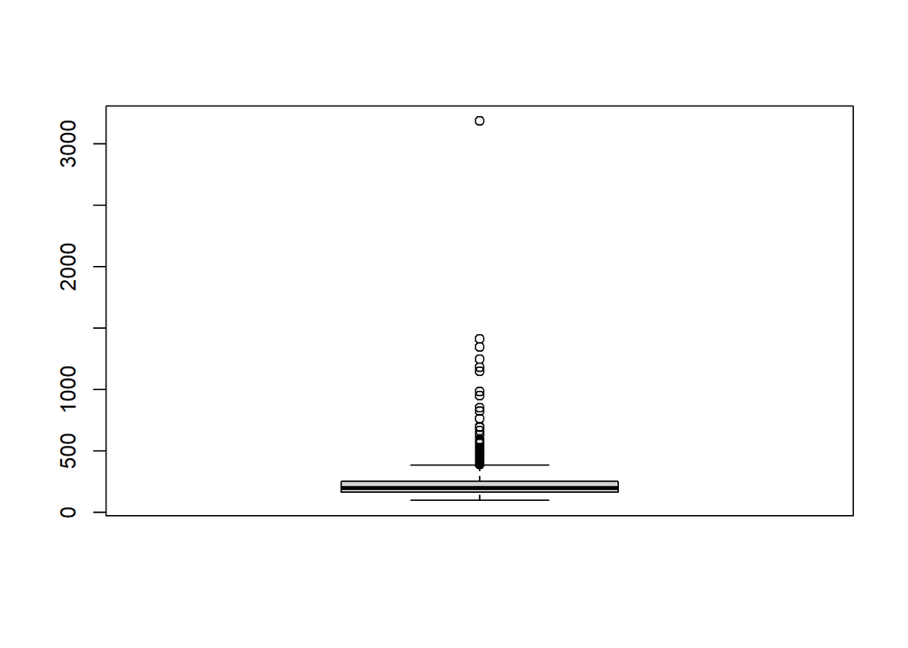

```
##  [1]  949  429  561  489  467  415  489  455  507  399  574  392  414  828  420
## [16]  983  853  693 1150  475  462  493  416  527  496  448  418  440  597  405
## [31]  391  460  398  465  415  393  395  401  392  403  431  410  416  395  397
## [46]  465  504 1349  665  503  483  410  447  442  406  457  512  479  763  396
## [61]  407  560  507  417  426  428  392  424  501  414  407  460 1182  413  463
## [76]  487  482  399  500  406 1414  496  697 3183 1247  464  456  583  632  573
## [91]  408
```

```r
# remove outliers using the boxplot method
boxplot(Fixdata5$FIRST_FIX_DUR, plot=TRUE)$out
```

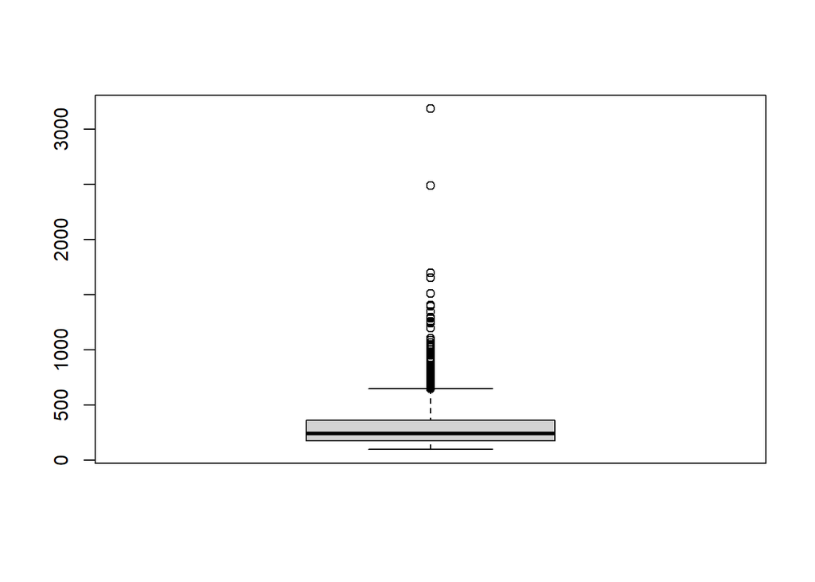

```
##  [1]  949 1406  790  974 1050  730 1196  711  718 1108  700  828  901  983  770
## [16]  722 2489  853 1036  693 1287  929  651  650  809 1025  678  799 1107  705
## [31]  715  848  679  703  801 1241  834  701  910 1299  822  741  667  848  747
## [46] 1396  891 1068  866 1042 1349  818  836 1300  721  651  849  752  789  731
## [61]  860  668 1088 1696  763  889  897 1039  824  969  706  662  722  752  814
## [76]  666  725  760  688  794  791  730 1513  670  686 1652  697 3183  706 1247
## [91]  663  807 1257 1009  755
```

```r
boxplot(Fixdata5$FIRST_PASS_DURATION, plot=TRUE)$out
```

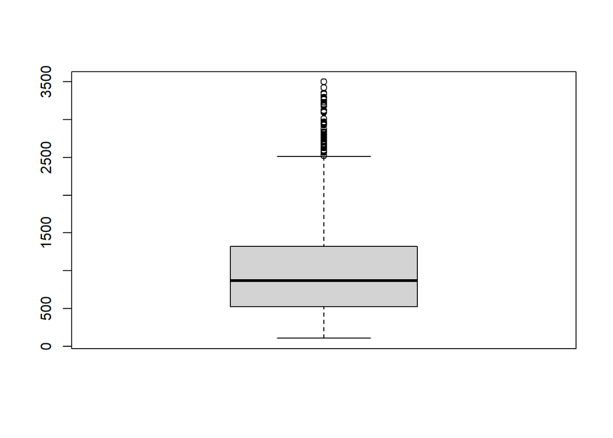

```
##  [1] 2832 3229 2700 2569 2809 3116 2825 2597 2778 3124 2932 3111 3264 2589 2773
## [16] 2960 2740 2525 2766 2679 2745 3426 3499 3123 2788 2714 2874 2788 2969 2760
## [31] 3207 2873 3289 3337 2946 2839 3352 2567 2580 2807 3297 2966 2668 2803 2795
## [46] 2677 2835 3196 2930 2715 3012 2721 3099 2635 2623 2704 3183
```

```r
boxplot(Fixdata5$TOTAL_DURATION, plot=TRUE)$out
```

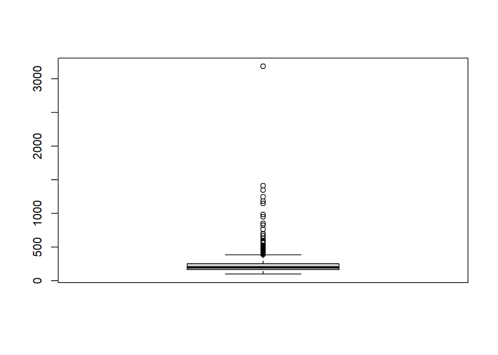

```r
outliers <- boxplot(Fixdata5$FIRST_FIX_DUR, plot=TRUE)$out
```

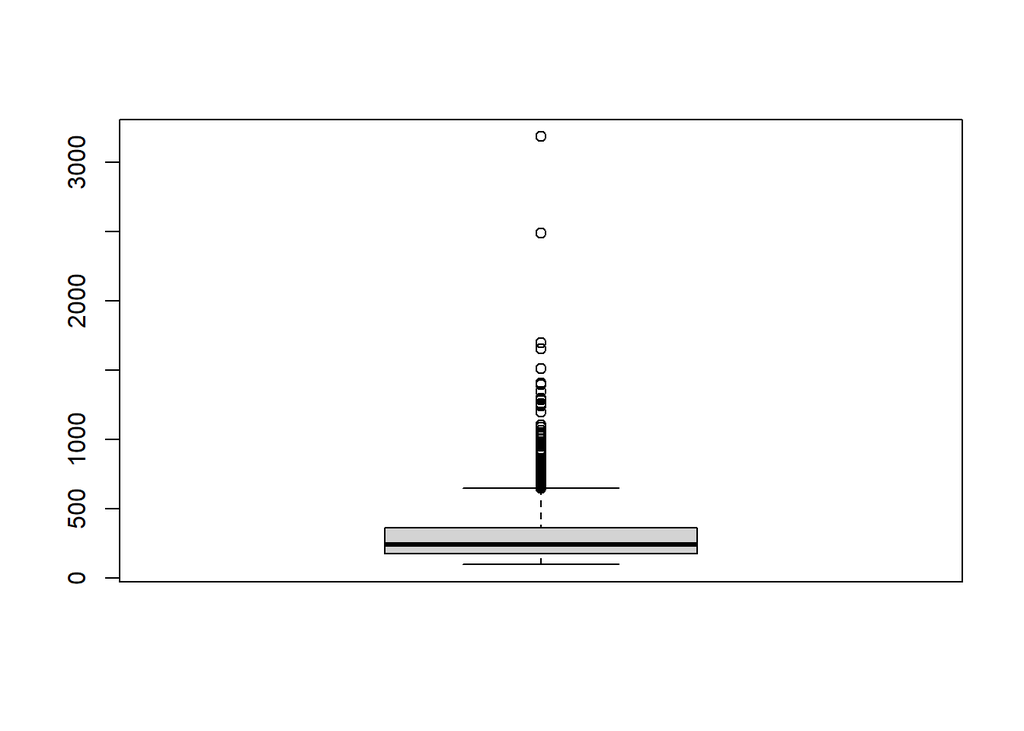

```r
outliers_first_pass <- boxplot(Fixdata5$FIRST_PASS_DURATION, plot=TRUE)$out
```

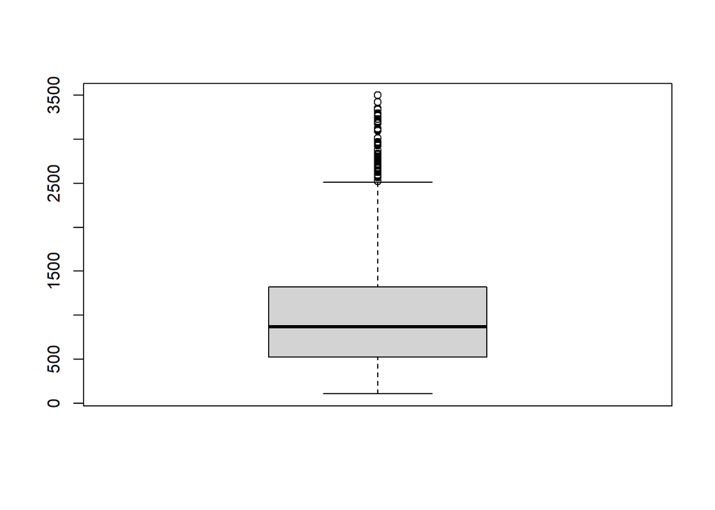

```r
outliers_total <- boxplot(Fixdata5$TOTAL_DURATION, plot=TRUE)$out
```

```r
Fixdata5<- Fixdata5[-which(Fixdata5$FIRST_FIX_DUR %in% outliers),]
Fixdata5<- Fixdata5[-which(Fixdata5$FIRST_PASS_DURATION %in% outliers_first_pass),]
Fixdata5<- Fixdata5[-which(Fixdata5$TOTAL_DURATION %in% outliers_total),]
```

# 8 Plot first fixation duration data

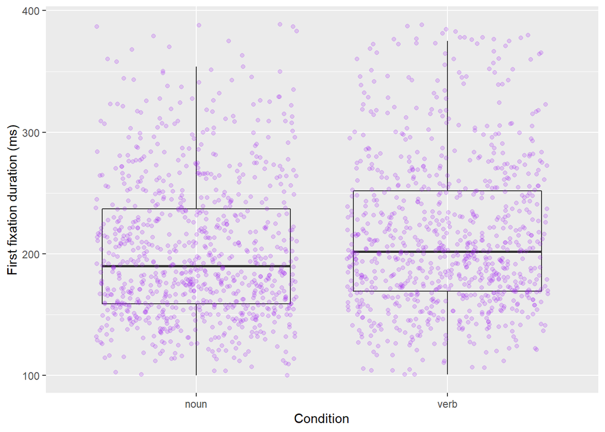

```r
library(ggplot2)


ggplot(data = Fixdata5,mapping = aes(x = condition, y = FIRST_FIX_DUR)) +
    geom_boxplot(alpha = 0) +
    geom_jitter(alpha = 0.2, color = "purple")+
  xlab("Condition") +
ylab("First fixation duration (ms)")
```

```r
  ylim(0,400)
```

```
## <ScaleContinuousPosition>
##  Range:
##  Limits:    0 --  400
```

# 9 Descriptive statistics

```r
library(tidyverse)
Fixdata6 <- Fixdata5 %>%
  filter(condition == "noun")


library(psych)
describe(Fixdata6$FIRST_FIX_DUR)
```

```
##    vars   n   mean    sd median trimmed   mad min max range skew kurtosis   se
## X1    1 872 202.57 57.91    190  197.23 53.37 100 389   289 0.81      0.2 1.96
```

```r
describe(Fixdata6$FIRST_PASS_DURATION)
```

```
##    vars   n   mean    sd median trimmed   mad min max range skew kurtosis   se
## X1    1 872 239.11 99.38  210.5  225.11 77.84 100 647   547 1.35     1.76 3.37
```

```r
describe(Fixdata6$TOTAL_DURATION)
```

```
##    vars   n   mean     sd median trimmed    mad min  max range skew kurtosis
## X1    1 872 734.47 440.13    651  689.54 420.32 107 2489  2382 0.97     0.88
##      se
## X1 14.9
```

```r
Fixdata7 <- Fixdata5 %>%
  filter(condition == "verb")


describe(Fixdata7$FIRST_FIX_DUR)
```

```
##    vars   n  mean   sd median trimmed   mad min max range skew kurtosis  se
## X1    1 858 214.6 61.6    202  208.97 56.34 101 388   287 0.78     0.13 2.1
```

```r
describe(Fixdata7$FIRST_PASS_DURATION)
```

```
##    vars   n   mean     sd median trimmed    mad min max range skew kurtosis
## X1    1 858 281.86 121.48    250  268.11 114.16 101 648   547 0.88     0.02
##      se
## X1 4.15
```

```r
describe(Fixdata7$TOTAL_DURATION)
```

```
##    vars   n    mean     sd median trimmed    mad min  max range skew kurtosis
## X1    1 858 1081.25 551.48   1019 1054.87 609.35 126 2514  2388 0.41    -0.54
##       se
## X1 18.83
```

# 10 Plot first pass duration data

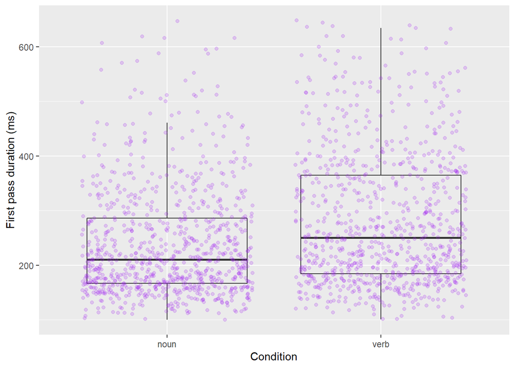

```r
library(ggplot2)

ggplot(data = Fixdata5, mapping = aes(x = condition, y = FIRST_PASS_DURATION)) +
    geom_boxplot(alpha = 0) +
  xlab("Condition") +
ylab("First pass duration (ms)")+
    geom_jitter(alpha = 0.2, color = "purple")
```

# Plot total pass duration data

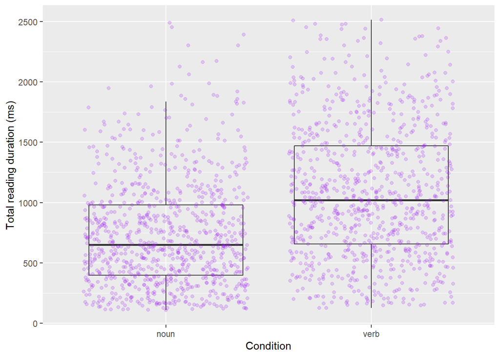

```r
library(ggplot2)

ggplot(data = Fixdata5, mapping = aes(x = condition, y = TOTAL_DURATION)) +
    geom_boxplot(alpha = 0) +
   xlab("Condition") +
ylab("Total reading duration (ms)")+
  geom_jitter(alpha = 0.2, color = "purple")
```

# 11 First fixation duration

```r
# remove the rows with missing values in the cognitive flexibility tasks in order to compare the models
Fixdata5 <- Fixdata5 %>%
  filter(performance != "NA" & SwitchingCost != "NA" & MixingCost != "NA")
```

```r
# Test the null hypothesis that there is no difference in first fixation duration between the noun and the denominal verb condition, with condition as fixed effect and random intercepts for subjects

library(lmerTest)
mixedModel1  =lmer(FIRST_FIX_DUR ~ condition + (1|RECORDING_SESSION_LABEL) , data=Fixdata5)
summary(mixedModel1)
```

```
## Linear mixed model fit by REML. t-tests use Satterthwaite's method [
## lmerModLmerTest]
## Formula: FIRST_FIX_DUR ~ condition + (1 | RECORDING_SESSION_LABEL)
##    Data: Fixdata5
##
## REML criterion at convergence: 16453.6
##
## Scaled residuals:
##     Min      1Q  Median      3Q     Max
## -2.6624 -0.7069 -0.1592  0.5572  3.4393
##
## Random effects:
##  Groups                  Name        Variance Std.Dev.
##  RECORDING_SESSION_LABEL (Intercept)  467.7   21.63
##  Residual                            3106.0   55.73
## Number of obs: 1508, groups:  RECORDING_SESSION_LABEL, 26
##
## Fixed effects:
##               Estimate Std. Error       df t value Pr(>|t|)
## (Intercept)    204.889      4.705   30.232  43.547  < 2e-16 ***
## conditionverb   11.026      2.875 1482.354   3.835 0.000131 ***
## ---
## Signif. codes:  0 '***' 0.001 '**' 0.01 '*' 0.05 '.' 0.1 ' ' 1
##
## Correlation of Fixed Effects:
##             (Intr)
## conditinvrb -0.303
```

```r
library(EMAtools)
lme.dscore(mixedModel1, Fixdata5, type = "lme4")
```

```
##                      t       df         d
## conditionverb 3.834517 1482.354 0.1991887
```

We observe a higly significant p-value for the denominal verb condition. Thus it is unlikely to observe a relationship between the predictor (condition) and response (first fixation duration) variables due to chance. Our hypothesis test shows that individuals had longer first fixation duration to our critical verbs compared to their parent nouns.

```r
# Model with condition as fixed effect and random intercepts for items

mixedModel2  =lmer(FIRST_FIX_DUR ~ condition + (1|item) , data=Fixdata5)
summary(mixedModel2)
```

```
## Linear mixed model fit by REML. t-tests use Satterthwaite's method [
## lmerModLmerTest]
## Formula: FIRST_FIX_DUR ~ condition + (1 | item)
##    Data: Fixdata5
##
## REML criterion at convergence: 16595.2
##
## Scaled residuals:
##     Min      1Q  Median      3Q     Max
## -1.8724 -0.7423 -0.1974  0.5922  3.1946
##
## Random effects:
##  Groups   Name        Variance Std.Dev.
##  item     (Intercept)   58.89   7.674
##  Residual             3494.05  59.110
## Number of obs: 1508, groups:  item, 68
##
## Fixed effects:
##               Estimate Std. Error      df t value Pr(>|t|)
## (Intercept)    203.343      2.521  67.570  80.655  < 2e-16 ***
## conditionverb   10.627      3.572  68.121   2.975  0.00405 **
## ---
## Signif. codes:  0 '***' 0.001 '**' 0.01 '*' 0.05 '.' 0.1 ' ' 1
##
## Correlation of Fixed Effects:
##             (Intr)
## conditinvrb -0.706
```

```r
lme.dscore(mixedModel2, Fixdata5, type = "lme4")
```

```
##                      t       df         d
## conditionverb 2.974846 68.12055 0.7208673
```

```r
anova(mixedModel1, mixedModel2)
```

```
## refitting model(s) with ML (instead of REML)
```

```
## Data: Fixdata5
## Models:
## mixedModel1: FIRST_FIX_DUR ~ condition + (1 | RECORDING_SESSION_LABEL)
## mixedModel2: FIRST_FIX_DUR ~ condition + (1 | item)
##             npar   AIC   BIC  logLik deviance Chisq Df Pr(>Chisq)
## mixedModel1    4 16470 16492 -8231.2    16462
## mixedModel2    4 16611 16632 -8301.3    16603     0  0
```

Model 1 is better than model 2 (AIC = 16470).

```r
# Model with condition and critical word length as fixed effects and random intercepts for subjects

mixedModel3  =lmer(FIRST_FIX_DUR ~ condition + critical_word_length + (1|RECORDING_SESSION_LABEL), data=Fixdata5)
summary(mixedModel3)
```

```
## Linear mixed model fit by REML. t-tests use Satterthwaite's method [
## lmerModLmerTest]
## Formula:
## FIRST_FIX_DUR ~ condition + critical_word_length + (1 | RECORDING_SESSION_LABEL)
##    Data: Fixdata5
##
## REML criterion at convergence: 16442.6
##
## Scaled residuals:
##     Min      1Q  Median      3Q     Max
## -2.6921 -0.7191 -0.1648  0.5826  3.3906
##
## Random effects:
##  Groups                  Name        Variance Std.Dev.
##  RECORDING_SESSION_LABEL (Intercept)  463.9   21.54
##  Residual                            3088.5   55.57
## Number of obs: 1508, groups:  RECORDING_SESSION_LABEL, 26
##
## Fixed effects:
##                       Estimate Std. Error        df t value Pr(>|t|)
## (Intercept)           221.1628     7.0438  148.6678  31.398  < 2e-16 ***
## conditionverb          13.7255     2.9971 1481.0681   4.580 5.05e-06 ***
## critical_word_length   -2.4993     0.8075 1480.7109  -3.095  0.00201 **
## ---
## Signif. codes:  0 '***' 0.001 '**' 0.01 '*' 0.05 '.' 0.1 ' ' 1
##
## Correlation of Fixed Effects:
##             (Intr) cndtnv
## conditinvrb  0.024
## crtcl_wrd_l -0.746 -0.291
```

```r
library(EMAtools)
lme.dscore(mixedModel3, Fixdata5, type = "lme4")
```

```
##                              t       df          d
## conditionverb         4.579594 1481.068  0.2379959
## critical_word_length -3.094975 1480.711 -0.1608614
```

The effect of the critical words’ length is significant (p < 0.01). It is a negative effect which means that with every added value on the used word length scale, first fixation duration is expected to decrease with -2.49. Participants had shorter first fixation duration to the longer critical words.

```r
data$critical_word_length <- as.numeric(data$critical_word_length)

df <- data %>%
  filter(critical_word_length != "NA") %>%
  group_by(condition) %>%
  summarize(mean_lenght = mean(critical_word_length))
df
```

```
## # A tibble: 4 x 2
##   condition          mean_lenght
##   <chr>                    <dbl>
## 1 conventional_verbs        6.72
## 2 nonsensical               5.38
## 3 noun                      6.57
## 4 verb                      7.65
```

```r
anova(mixedModel1, mixedModel3)
```

```
## refitting model(s) with ML (instead of REML)
```

```
## Data: Fixdata5
## Models:
## mixedModel1: FIRST_FIX_DUR ~ condition + (1 | RECORDING_SESSION_LABEL)
## mixedModel3: FIRST_FIX_DUR ~ condition + critical_word_length + (1 | RECORDING_SESSION_LABEL)
##             npar   AIC   BIC  logLik deviance  Chisq Df Pr(>Chisq)
## mixedModel1    4 16470 16492 -8231.2    16462
## mixedModel3    5 16463 16489 -8226.4    16453 9.5691  1   0.001979 **
## ---
## Signif. codes:  0 '***' 0.001 '**' 0.01 '*' 0.05 '.' 0.1 ' ' 1
```

The results of the anova show that model 3 is better than model 1. Critical word length significantly improves the model.

```r
# Model with interaction between condition and critical word length and random intercept for subjects

mixedModel4 <- lmer(FIRST_FIX_DUR ~ condition * critical_word_length + (1|RECORDING_SESSION_LABEL) , data=Fixdata5)
summary(mixedModel4)
```

```
## Linear mixed model fit by REML. t-tests use Satterthwaite's method [
## lmerModLmerTest]
## Formula:
## FIRST_FIX_DUR ~ condition * critical_word_length + (1 | RECORDING_SESSION_LABEL)
##    Data: Fixdata5
##
## REML criterion at convergence: 16438
##
## Scaled residuals:
##     Min      1Q  Median      3Q     Max
## -2.6800 -0.7132 -0.1659  0.5649  3.4015
##
## Random effects:
##  Groups                  Name        Variance Std.Dev.
##  RECORDING_SESSION_LABEL (Intercept)  464.4   21.55
##  Residual                            3086.7   55.56
## Number of obs: 1508, groups:  RECORDING_SESSION_LABEL, 26
##
## Fixed effects:
##                                    Estimate Std. Error       df t value
## (Intercept)                         227.788      8.581  302.217  26.545
## conditionverb                        -1.785     11.858 1479.434  -0.151
## critical_word_length                 -3.517      1.104 1479.427  -3.186
## conditionverb:critical_word_length    2.188      1.618 1479.492   1.352
##                                    Pr(>|t|)
## (Intercept)                         < 2e-16 ***
## conditionverb                       0.88036
## critical_word_length                0.00147 **
## conditionverb:critical_word_length  0.17662
## ---
## Signif. codes:  0 '***' 0.001 '**' 0.01 '*' 0.05 '.' 0.1 ' ' 1
##
## Correlation of Fixed Effects:
##             (Intr) cndtnv crtc__
## conditinvrb -0.548
## crtcl_wrd_l -0.838  0.606
## cndtnvrb:__  0.571 -0.968 -0.682
```

```r
library(EMAtools)
lme.dscore(mixedModel4, Fixdata5, type = "lme4")
```

```
##                                             t       df            d
## conditionverb                      -0.1505424 1479.434 -0.007827822
## critical_word_length               -3.1862949 1479.427 -0.165679651
## conditionverb:critical_word_length  1.3518655 1479.492  0.070292202
```

```r
anova(mixedModel3, mixedModel4) # critical word length in interaction with condition does not significantly improve the model
```

```
## refitting model(s) with ML (instead of REML)
```

```
## Data: Fixdata5
## Models:
## mixedModel3: FIRST_FIX_DUR ~ condition + critical_word_length + (1 | RECORDING_SESSION_LABEL)
## mixedModel4: FIRST_FIX_DUR ~ condition * critical_word_length + (1 | RECORDING_SESSION_LABEL)
##             npar   AIC   BIC  logLik deviance  Chisq Df Pr(>Chisq)
## mixedModel3    5 16463 16489 -8226.4    16453
## mixedModel4    6 16463 16495 -8225.5    16451 1.8292  1     0.1762
```

Model with condition * critical word length is not significantly better than the model with condition and critical word length as fixed effects.

```r
# Model with syllable count, condition and critical word length as fixed effects

mixedModel5 <- lmer(FIRST_FIX_DUR ~ condition + syllable_count + critical_word_length + (1|RECORDING_SESSION_LABEL) , data=Fixdata5)
summary(mixedModel5)
```

```
## Linear mixed model fit by REML. t-tests use Satterthwaite's method [
## lmerModLmerTest]
## Formula: FIRST_FIX_DUR ~ condition + syllable_count + critical_word_length +
##     (1 | RECORDING_SESSION_LABEL)
##    Data: Fixdata5
##
## REML criterion at convergence: 16437.6
##
## Scaled residuals:
##     Min      1Q  Median      3Q     Max
## -2.7427 -0.7135 -0.1698  0.5753  3.3989
##
## Random effects:
##  Groups                  Name        Variance Std.Dev.
##  RECORDING_SESSION_LABEL (Intercept)  464.2   21.54
##  Residual                            3088.0   55.57
## Number of obs: 1508, groups:  RECORDING_SESSION_LABEL, 26
##
## Fixed effects:
##                       Estimate Std. Error        df t value Pr(>|t|)
## (Intercept)           222.7391     7.1825  159.8002  31.011  < 2e-16 ***
## conditionverb          13.8071     2.9977 1480.0744   4.606 4.46e-06 ***
## syllable_count         -3.0147     2.6842 1479.8248  -1.123   0.2616
## critical_word_length   -1.9159     0.9601 1479.8106  -1.995   0.0462 *
## ---
## Signif. codes:  0 '***' 0.001 '**' 0.01 '*' 0.05 '.' 0.1 ' ' 1
##
## Correlation of Fixed Effects:
##             (Intr) cndtnv syllb_
## conditinvrb  0.028
## syllabl_cnt -0.195 -0.024
## crtcl_wrd_l -0.510 -0.232 -0.541
```

```r
library(EMAtools)
lme.dscore(mixedModel5, Fixdata5, type = "lme4")
```

```
##                              t       df           d
## conditionverb         4.605897 1480.074  0.23944319
## syllable_count       -1.123108 1479.825 -0.05839108
## critical_word_length -1.995403 1479.811 -0.10374271
```

```r
anova(mixedModel3, mixedModel5) # adding syllable count does not significantly improve the model
```

```
## refitting model(s) with ML (instead of REML)
```

```
## Data: Fixdata5
## Models:
## mixedModel3: FIRST_FIX_DUR ~ condition + critical_word_length + (1 | RECORDING_SESSION_LABEL)
## mixedModel5: FIRST_FIX_DUR ~ condition + syllable_count + critical_word_length + (1 | RECORDING_SESSION_LABEL)
##             npar   AIC   BIC  logLik deviance  Chisq Df Pr(>Chisq)
## mixedModel3    5 16463 16489 -8226.4    16453
## mixedModel5    6 16464 16496 -8225.8    16452 1.2629  1     0.2611
```

The anova shows that model 3 is better than model 5.

```r
# Model with condition, aprime (N-back scores), critical word length as fixed effect and random intercept for subjects

mixedModel6 <- lmer(FIRST_FIX_DUR ~ condition + aprime + critical_word_length + (1 | RECORDING_SESSION_LABEL) , data=Fixdata5)
summary(mixedModel6)
```

```
## Linear mixed model fit by REML. t-tests use Satterthwaite's method [
## lmerModLmerTest]
## Formula: FIRST_FIX_DUR ~ condition + aprime + critical_word_length + (1 |
##     RECORDING_SESSION_LABEL)
##    Data: Fixdata5
##
## REML criterion at convergence: 16431.9
##
## Scaled residuals:
##     Min      1Q  Median      3Q     Max
## -2.6864 -0.7178 -0.1638  0.5722  3.3947
##
## Random effects:
##  Groups                  Name        Variance Std.Dev.
##  RECORDING_SESSION_LABEL (Intercept)  451.8   21.26
##  Residual                            3088.5   55.57
## Number of obs: 1508, groups:  RECORDING_SESSION_LABEL, 26
##
## Fixed effects:
##                       Estimate Std. Error        df t value Pr(>|t|)
## (Intercept)           264.9560    35.3304   29.2583   7.499 2.73e-08 ***
## conditionverb          13.7206     2.9971 1481.0848   4.578 5.09e-06 ***
## aprime                -47.8874    37.8645   27.6776  -1.265  0.21652
## critical_word_length   -2.5023     0.8075 1480.7115  -3.099  0.00198 **
## ---
## Signif. codes:  0 '***' 0.001 '**' 0.01 '*' 0.05 '.' 0.1 ' ' 1
##
## Correlation of Fixed Effects:
##             (Intr) cndtnv aprime
## conditinvrb  0.004
## aprime      -0.980  0.001
## crtcl_wrd_l -0.151 -0.291  0.002
```

```r
library(EMAtools)
lme.dscore(mixedModel6, Fixdata5, type = "lme4")
```

```
##                              t         df          d
## conditionverb         4.577978 1481.08482  0.2379106
## aprime               -1.264705   27.67755 -0.4807900
## critical_word_length -3.098638 1480.71151 -0.1610518
```

```r
anova(mixedModel3, mixedModel6) # adding aprime does not significantly improve the model
```

```
## refitting model(s) with ML (instead of REML)
```

```
## Data: Fixdata5
## Models:
## mixedModel3: FIRST_FIX_DUR ~ condition + critical_word_length + (1 | RECORDING_SESSION_LABEL)
## mixedModel6: FIRST_FIX_DUR ~ condition + aprime + critical_word_length + (1 | RECORDING_SESSION_LABEL)
##             npar   AIC   BIC  logLik deviance  Chisq Df Pr(>Chisq)
## mixedModel3    5 16463 16489 -8226.4    16453
## mixedModel6    6 16463 16495 -8225.6    16451 1.6719  1      0.196
```

Model 3 with condition and critical word length as fixed effects is better than model 6.

```r
# Model with interaction between aprime (N-back scores) and condition, critical word length as fixed effect and random intercept for subjects

mixedModel7 <- lmer(FIRST_FIX_DUR ~ condition + aprime + critical_word_length + (1 | RECORDING_SESSION_LABEL) , data=Fixdata5)
summary(mixedModel7)
```

```
## Linear mixed model fit by REML. t-tests use Satterthwaite's method [
## lmerModLmerTest]
## Formula: FIRST_FIX_DUR ~ condition + aprime + critical_word_length + (1 |
##     RECORDING_SESSION_LABEL)
##    Data: Fixdata5
##
## REML criterion at convergence: 16431.9
##
## Scaled residuals:
##     Min      1Q  Median      3Q     Max
## -2.6864 -0.7178 -0.1638  0.5722  3.3947
##
## Random effects:
##  Groups                  Name        Variance Std.Dev.
##  RECORDING_SESSION_LABEL (Intercept)  451.8   21.26
##  Residual                            3088.5   55.57
## Number of obs: 1508, groups:  RECORDING_SESSION_LABEL, 26
##
## Fixed effects:
##                       Estimate Std. Error        df t value Pr(>|t|)
## (Intercept)           264.9560    35.3304   29.2583   7.499 2.73e-08 ***
## conditionverb          13.7206     2.9971 1481.0848   4.578 5.09e-06 ***
## aprime                -47.8874    37.8645   27.6776  -1.265  0.21652
## critical_word_length   -2.5023     0.8075 1480.7115  -3.099  0.00198 **
## ---
## Signif. codes:  0 '***' 0.001 '**' 0.01 '*' 0.05 '.' 0.1 ' ' 1
##
## Correlation of Fixed Effects:
##             (Intr) cndtnv aprime
## conditinvrb  0.004
## aprime      -0.980  0.001
## crtcl_wrd_l -0.151 -0.291  0.002
```

```r
library(EMAtools)
lme.dscore(mixedModel7, Fixdata5, type = "lme4")
```

```
##                              t         df          d
## conditionverb         4.577978 1481.08482  0.2379106
## aprime               -1.264705   27.67755 -0.4807900
## critical_word_length -3.098638 1480.71151 -0.1610518
```

```r
anova(mixedModel3, mixedModel7) # adding the interaction between aprime and condition does not significantly improve the model
```

```
## refitting model(s) with ML (instead of REML)
```

```
## Data: Fixdata5
## Models:
## mixedModel3: FIRST_FIX_DUR ~ condition + critical_word_length + (1 | RECORDING_SESSION_LABEL)
## mixedModel7: FIRST_FIX_DUR ~ condition + aprime + critical_word_length + (1 | RECORDING_SESSION_LABEL)
##             npar   AIC   BIC  logLik deviance  Chisq Df Pr(>Chisq)
## mixedModel3    5 16463 16489 -8226.4    16453
## mixedModel7    6 16463 16495 -8225.6    16451 1.6719  1      0.196
```

```r
# Model with performance (Flanker scores), critical word length as fixed effect and random intercept for subjects

mixedModel8 <- lmer(FIRST_FIX_DUR ~ condition + performance + critical_word_length + (1 | RECORDING_SESSION_LABEL) , data=Fixdata5)
summary(mixedModel8)
```

```
## Linear mixed model fit by REML. t-tests use Satterthwaite's method [
## lmerModLmerTest]
## Formula: FIRST_FIX_DUR ~ condition + performance + critical_word_length +
##     (1 | RECORDING_SESSION_LABEL)
##    Data: Fixdata5
##
## REML criterion at convergence: 16430.5
##
## Scaled residuals:
##     Min      1Q  Median      3Q     Max
## -2.6950 -0.7190 -0.1656  0.5827  3.3912
##
## Random effects:
##  Groups                  Name        Variance Std.Dev.
##  RECORDING_SESSION_LABEL (Intercept)  485.4   22.03
##  Residual                            3088.5   55.57
## Number of obs: 1508, groups:  RECORDING_SESSION_LABEL, 26
##
## Fixed effects:
##                       Estimate Std. Error        df t value Pr(>|t|)
## (Intercept)           220.9184    10.1294   47.1940  21.810  < 2e-16 ***
## conditionverb          13.7272     2.9971 1481.0093   4.580 5.04e-06 ***
## performance             5.9525   174.7739   24.4513   0.034  0.97311
## critical_word_length   -2.4983     0.8075 1480.6552  -3.094  0.00201 **
## ---
## Signif. codes:  0 '***' 0.001 '**' 0.01 '*' 0.05 '.' 0.1 ' ' 1
##
## Correlation of Fixed Effects:
##             (Intr) cndtnv prfrmn
## conditinvrb  0.016
## performance -0.713  0.001
## crtcl_wrd_l -0.518 -0.291 -0.002
```

```r
library(EMAtools)
lme.dscore(mixedModel8, Fixdata5, type = "lme4")
```

```
##                                t         df           d
## conditionverb         4.58012824 1481.00929  0.23802838
## performance           0.03405805   24.45134  0.01377522
## critical_word_length -3.09374875 1480.65520 -0.16080075
```

```r
anova(mixedModel3, mixedModel8) # adding performance does not significantly improve the model
```

```
## refitting model(s) with ML (instead of REML)
```

```
## Data: Fixdata5
## Models:
## mixedModel3: FIRST_FIX_DUR ~ condition + critical_word_length + (1 | RECORDING_SESSION_LABEL)
## mixedModel8: FIRST_FIX_DUR ~ condition + performance + critical_word_length + (1 | RECORDING_SESSION_LABEL)
##             npar   AIC   BIC  logLik deviance Chisq Df Pr(>Chisq)
## mixedModel3    5 16463 16489 -8226.4    16453
## mixedModel8    6 16465 16497 -8226.4    16453 0.001  1     0.9746
```

```r
# Model with interaction between condition and performance (Flanker scores), critical word length as fixed effect and random intercept for subjects

mixedModel9 <- lmer(FIRST_FIX_DUR ~ condition * performance + critical_word_length + (1 | RECORDING_SESSION_LABEL) , data=Fixdata5)
summary(mixedModel9)
```

```
## Linear mixed model fit by REML. t-tests use Satterthwaite's method [
## lmerModLmerTest]
## Formula: FIRST_FIX_DUR ~ condition * performance + critical_word_length +
##     (1 | RECORDING_SESSION_LABEL)
##    Data: Fixdata5
##
## REML criterion at convergence: 16419
##
## Scaled residuals:
##     Min      1Q  Median      3Q     Max
## -2.6940 -0.7186 -0.1631  0.5835  3.4014
##
## Random effects:
##  Groups                  Name        Variance Std.Dev.
##  RECORDING_SESSION_LABEL (Intercept)  485.4   22.03
##  Residual                            3090.3   55.59
## Number of obs: 1508, groups:  RECORDING_SESSION_LABEL, 26
##
## Fixed effects:
##                            Estimate Std. Error        df t value Pr(>|t|)
## (Intercept)                219.9921    10.4023   52.4174  21.148  < 2e-16 ***
## conditionverb               15.5219     5.4701 1479.9677   2.838  0.00461 **
## performance                 28.0713   183.6586   29.7976   0.153  0.87955
## critical_word_length        -2.4938     0.8079 1479.6489  -3.087  0.00206 **
## conditionverb:performance  -44.4076   113.2157 1479.5451  -0.392  0.69494
## ---
## Signif. codes:  0 '***' 0.001 '**' 0.01 '*' 0.05 '.' 0.1 ' ' 1
##
## Correlation of Fixed Effects:
##             (Intr) cndtnv prfrmn crtc__
## conditinvrb -0.181
## performance -0.731  0.257
## crtcl_wrd_l -0.507 -0.148  0.002
## cndtnvrb:pr  0.227 -0.836 -0.307 -0.014
```

```r
library(EMAtools)
lme.dscore(mixedModel9, Fixdata5, type = "lme4")
```

```
##                                    t         df           d
## conditionverb              2.8375761 1479.96766  0.14752017
## performance                0.1528450   29.79759  0.05600033
## critical_word_length      -3.0869732 1479.64885 -0.16050314
## conditionverb:performance -0.3922394 1479.54505 -0.02039469
```

```r
anova(mixedModel3, mixedModel9) # adding the interaction between condition and performance does not significantly improve the model
```

```
## refitting model(s) with ML (instead of REML)
```

```
## Data: Fixdata5
## Models:
## mixedModel3: FIRST_FIX_DUR ~ condition + critical_word_length + (1 | RECORDING_SESSION_LABEL)
## mixedModel9: FIRST_FIX_DUR ~ condition * performance + critical_word_length + (1 | RECORDING_SESSION_LABEL)
##             npar   AIC   BIC  logLik deviance Chisq Df Pr(>Chisq)
## mixedModel3    5 16463 16489 -8226.4    16453
## mixedModel9    7 16467 16504 -8226.3    16453 0.155  2     0.9254
```

```r
# Model with condition, Switching cost (Set-shifting scores), critical word length as fixed effect and random intercept for subjects

mixedModel10 <- lmer(FIRST_FIX_DUR ~ condition + SwitchingCost + critical_word_length + (1 | RECORDING_SESSION_LABEL) , data=Fixdata5)
summary(mixedModel10)
```

```
## Linear mixed model fit by REML. t-tests use Satterthwaite's method [
## lmerModLmerTest]
## Formula: FIRST_FIX_DUR ~ condition + SwitchingCost + critical_word_length +
##     (1 | RECORDING_SESSION_LABEL)
##    Data: Fixdata5
##
## REML criterion at convergence: 16431.5
##
## Scaled residuals:
##     Min      1Q  Median      3Q     Max
## -2.6930 -0.7191 -0.1670  0.5836  3.3929
##
## Random effects:
##  Groups                  Name        Variance Std.Dev.
##  RECORDING_SESSION_LABEL (Intercept)  481.2   21.94
##  Residual                            3088.6   55.58
## Number of obs: 1508, groups:  RECORDING_SESSION_LABEL, 26
##
## Fixed effects:
##                       Estimate Std. Error        df t value Pr(>|t|)
## (Intercept)           220.0011     7.6690   96.8960  28.687  < 2e-16 ***
## conditionverb          13.7262     2.9972 1480.9660   4.580 5.05e-06 ***
## SwitchingCost          38.2948    96.1825   24.1133   0.398  0.69403
## critical_word_length   -2.4984     0.8075 1480.6193  -3.094  0.00201 **
## ---
## Signif. codes:  0 '***' 0.001 '**' 0.01 '*' 0.05 '.' 0.1 ' ' 1
##
## Correlation of Fixed Effects:
##             (Intr) cndtnv SwtchC
## conditinvrb  0.022
## SwitchngCst -0.381 -0.001
## crtcl_wrd_l -0.686 -0.291  0.000
```

```r
library(EMAtools)
lme.dscore(mixedModel10, Fixdata5, type = "lme4")
```

```
##                               t         df          d
## conditionverb         4.5797547 1480.96597  0.2380124
## SwitchingCost         0.3981466   24.11327  0.1621605
## critical_word_length -3.0938632 1480.61926 -0.1608087
```

```r
anova(mixedModel3, mixedModel10) # adding switching cost as a fixed effect did not improve the model
```

```
## refitting model(s) with ML (instead of REML)
```

```
## Data: Fixdata5
## Models:
## mixedModel3: FIRST_FIX_DUR ~ condition + critical_word_length + (1 | RECORDING_SESSION_LABEL)
## mixedModel10: FIRST_FIX_DUR ~ condition + SwitchingCost + critical_word_length + (1 | RECORDING_SESSION_LABEL)
##              npar   AIC   BIC  logLik deviance  Chisq Df Pr(>Chisq)
## mixedModel3     5 16463 16489 -8226.4    16453
## mixedModel10    6 16465 16497 -8226.3    16453 0.1737  1     0.6769
```

```r
# Model with interaction between condition and Switching cost (Set-shifting scores), critical word length as fixed effect and random intercept for subjects

mixedModel11 <- lmer(FIRST_FIX_DUR ~ condition * SwitchingCost + critical_word_length + (1 | RECORDING_SESSION_LABEL) , data=Fixdata5)
summary(mixedModel11)
```

```
## Linear mixed model fit by REML. t-tests use Satterthwaite's method [
## lmerModLmerTest]
## Formula: FIRST_FIX_DUR ~ condition * SwitchingCost + critical_word_length +
##     (1 | RECORDING_SESSION_LABEL)
##    Data: Fixdata5
##
## REML criterion at convergence: 16415.9
##
## Scaled residuals:
##     Min      1Q  Median      3Q     Max
## -2.7256 -0.7182 -0.1552  0.5806  3.4388
##
## Random effects:
##  Groups                  Name        Variance Std.Dev.
##  RECORDING_SESSION_LABEL (Intercept)  481.3   21.94
##  Residual                            3079.1   55.49
## Number of obs: 1508, groups:  RECORDING_SESSION_LABEL, 26
##
## Fixed effects:
##                              Estimate Std. Error        df t value Pr(>|t|)
## (Intercept)                  217.8771     7.7156   99.1967  28.239  < 2e-16 ***
## conditionverb                 18.4119     3.5917 1479.7649   5.126 3.35e-07 ***
## SwitchingCost                109.8184   100.8452   29.1404   1.089  0.28509
## critical_word_length          -2.5229     0.8064 1479.6068  -3.129  0.00179 **
## conditionverb:SwitchingCost -145.6233    61.7277 1479.7388  -2.359  0.01845 *
## ---
## Signif. codes:  0 '***' 0.001 '**' 0.01 '*' 0.05 '.' 0.1 ' ' 1
##
## Correlation of Fixed Effects:
##             (Intr) cndtnv SwtchC crtc__
## conditinvrb -0.046
## SwitchngCst -0.396  0.166
## crtcl_wrd_l -0.679 -0.250 -0.004
## cndtnvrb:SC  0.117 -0.553 -0.301  0.013
```

```r
library(EMAtools)
lme.dscore(mixedModel11, Fixdata5, type = "lme4")
```

```
##                                     t         df          d
## conditionverb                5.126283 1479.76490  0.2665239
## SwitchingCost                1.088981   29.14039  0.4034618
## critical_word_length        -3.128710 1479.60682 -0.1626755
## conditionverb:SwitchingCost -2.359123 1479.73879 -0.1226558
```

```r
anova(mixedModel3, mixedModel11) # adding the interaction between switching cost and condition improves the model
```

```
## refitting model(s) with ML (instead of REML)
```

```
## Data: Fixdata5
## Models:
## mixedModel3: FIRST_FIX_DUR ~ condition + critical_word_length + (1 | RECORDING_SESSION_LABEL)
## mixedModel11: FIRST_FIX_DUR ~ condition * SwitchingCost + critical_word_length + (1 | RECORDING_SESSION_LABEL)
##              npar   AIC   BIC  logLik deviance  Chisq Df Pr(>Chisq)
## mixedModel3     5 16463 16489 -8226.4    16453
## mixedModel11    7 16461 16498 -8223.5    16447 5.7402  2    0.05669 .
## ---
## Signif. codes:  0 '***' 0.001 '**' 0.01 '*' 0.05 '.' 0.1 ' ' 1
```

```r
# Model with Mixing cost (Set-shifting scores), critical word length as fixed effect and random intercept for subjects

mixedModel12 <- lmer(FIRST_FIX_DUR ~ condition + MixingCost  + critical_word_length + (1 | RECORDING_SESSION_LABEL) , data=Fixdata5)
summary(mixedModel12)
```

```
## Linear mixed model fit by REML. t-tests use Satterthwaite's method [
## lmerModLmerTest]
## Formula: FIRST_FIX_DUR ~ condition + MixingCost + critical_word_length +
##     (1 | RECORDING_SESSION_LABEL)
##    Data: Fixdata5
##
## REML criterion at convergence: 16428.2
##
## Scaled residuals:
##     Min      1Q  Median      3Q     Max
## -2.6897 -0.7201 -0.1704  0.5828  3.3800
##
## Random effects:
##  Groups                  Name        Variance Std.Dev.
##  RECORDING_SESSION_LABEL (Intercept)  399.5   19.99
##  Residual                            3088.8   55.58
## Number of obs: 1508, groups:  RECORDING_SESSION_LABEL, 26
##
## Fixed effects:
##                       Estimate Std. Error        df t value Pr(>|t|)
## (Intercept)           230.4871     8.1758   74.9061  28.191  < 2e-16 ***
## conditionverb          13.7081     2.9972 1480.9750   4.574 5.19e-06 ***
## MixingCost           -143.7624    68.4014   23.2969  -2.102  0.04658 *
## critical_word_length   -2.4989     0.8076 1480.5607  -3.094  0.00201 **
## ---
## Signif. codes:  0 '***' 0.001 '**' 0.01 '*' 0.05 '.' 0.1 ' ' 1
##
## Correlation of Fixed Effects:
##             (Intr) cndtnv MxngCs
## conditinvrb  0.020
## MixingCost  -0.543  0.002
## crtcl_wrd_l -0.642 -0.291 -0.002
```

```r
library(EMAtools)
lme.dscore(mixedModel12, Fixdata5, type = "lme4")
```

```
##                              t         df          d
## conditionverb         4.573703 1480.97502  0.2376972
## MixingCost           -2.101746   23.29691 -0.8708855
## critical_word_length -3.094415 1480.56066 -0.1608405
```

```r
anova(mixedModel11, mixedModel12) # adding Mixing Cost as a fixed effect does not significantly improve the model
```

```
## refitting model(s) with ML (instead of REML)
```

```
## Data: Fixdata5
## Models:
## mixedModel12: FIRST_FIX_DUR ~ condition + MixingCost + critical_word_length + (1 | RECORDING_SESSION_LABEL)
## mixedModel11: FIRST_FIX_DUR ~ condition * SwitchingCost + critical_word_length + (1 | RECORDING_SESSION_LABEL)
##              npar   AIC   BIC  logLik deviance  Chisq Df Pr(>Chisq)
## mixedModel12    6 16460 16492 -8224.2    16448
## mixedModel11    7 16461 16498 -8223.5    16447 1.3563  1     0.2442
```

```r
# Model with interaction between condition and Mixing cost (Set-shifting scores), critical word length as fixed effect and random intercept for subjects

mixedModel13 <- lmer(FIRST_FIX_DUR ~ condition * MixingCost  + critical_word_length + (1 | RECORDING_SESSION_LABEL) , data=Fixdata5)
summary(mixedModel13)
```

```
## Linear mixed model fit by REML. t-tests use Satterthwaite's method [
## lmerModLmerTest]
## Formula: FIRST_FIX_DUR ~ condition * MixingCost + critical_word_length +
##     (1 | RECORDING_SESSION_LABEL)
##    Data: Fixdata5
##
## REML criterion at convergence: 16415
##
## Scaled residuals:
##     Min      1Q  Median      3Q     Max
## -2.6712 -0.7227 -0.1622  0.5686  3.3597
##
## Random effects:
##  Groups                  Name        Variance Std.Dev.
##  RECORDING_SESSION_LABEL (Intercept)  399.5   19.99
##  Residual                            3083.1   55.53
## Number of obs: 1508, groups:  RECORDING_SESSION_LABEL, 26
##
## Fixed effects:
##                           Estimate Std. Error        df t value Pr(>|t|)
## (Intercept)               233.5906     8.3285   80.5638  28.047  < 2e-16 ***
## conditionverb               7.9025     4.2449 1479.4865   1.862  0.06285 .
## MixingCost               -188.3820    72.1938   28.9220  -2.609  0.01421 *
## critical_word_length       -2.5223     0.8069 1479.5557  -3.126  0.00181 **
## conditionverb:MixingCost   88.4280    45.8286 1479.2379   1.930  0.05386 .
## ---
## Signif. codes:  0 '***' 0.001 '**' 0.01 '*' 0.05 '.' 0.1 ' ' 1
##
## Correlation of Fixed Effects:
##             (Intr) cndtnv MxngCs crtc__
## conditinvrb -0.123
## MixingCost  -0.567  0.228
## crtcl_wrd_l -0.632 -0.195  0.003
## cndtnvrb:MC  0.193 -0.709 -0.320 -0.015
```

```r
library(EMAtools)
lme.dscore(mixedModel13, Fixdata5, type = "lme4")
```

```
##                                  t         df           d
## conditionverb             1.861630 1479.48651  0.09679832
## MixingCost               -2.609392   28.92197 -0.97041034
## critical_word_length     -3.125856 1479.55565 -0.16252992
## conditionverb:MixingCost  1.929538 1479.23795  0.10033775
```

```r
anova(mixedModel11, mixedModel13) # adding the interaction between condition and mixing scores improves the model
```

```
## refitting model(s) with ML (instead of REML)
```

```
## Data: Fixdata5
## Models:
## mixedModel11: FIRST_FIX_DUR ~ condition * SwitchingCost + critical_word_length + (1 | RECORDING_SESSION_LABEL)
## mixedModel13: FIRST_FIX_DUR ~ condition * MixingCost + critical_word_length + (1 | RECORDING_SESSION_LABEL)
##              npar   AIC   BIC  logLik deviance  Chisq Df Pr(>Chisq)
## mixedModel11    7 16461 16498 -8223.5    16447
## mixedModel13    7 16459 16496 -8222.3    16445 2.3703  0
```

```r
# Add CLIP_Q scores as fixed effect

mixedModel14 <- lmer(FIRST_FIX_DUR ~ condition * MixingCost  + critical_word_length + CLIP_Q + (1 | RECORDING_SESSION_LABEL) , data=Fixdata5)
summary(mixedModel14)
```

```
## Linear mixed model fit by REML. t-tests use Satterthwaite's method [
## lmerModLmerTest]
## Formula: FIRST_FIX_DUR ~ condition * MixingCost + critical_word_length +
##     CLIP_Q + (1 | RECORDING_SESSION_LABEL)
##    Data: Fixdata5
##
## REML criterion at convergence: 16414
##
## Scaled residuals:
##     Min      1Q  Median      3Q     Max
## -2.6751 -0.7225 -0.1612  0.5648  3.3588
##
## Random effects:
##  Groups                  Name        Variance Std.Dev.
##  RECORDING_SESSION_LABEL (Intercept)  418.9   20.47
##  Residual                            3083.1   55.53
## Number of obs: 1508, groups:  RECORDING_SESSION_LABEL, 26
##
## Fixed effects:
##                           Estimate Std. Error        df t value Pr(>|t|)
## (Intercept)               238.3448    25.8215   24.9319   9.230 1.61e-09 ***
## conditionverb               7.9075     4.2449 1479.4799   1.863  0.06269 .
## MixingCost               -186.4131    74.2290   27.4141  -2.511  0.01821 *
## critical_word_length       -2.5216     0.8069 1479.5545  -3.125  0.00181 **
## CLIP_Q                     -0.1251     0.6421   22.4864  -0.195  0.84726
## conditionverb:MixingCost   88.4403    45.8284 1479.2520   1.930  0.05382 .
## ---
## Signif. codes:  0 '***' 0.001 '**' 0.01 '*' 0.05 '.' 0.1 ' ' 1
##
## Correlation of Fixed Effects:
##             (Intr) cndtnv MxngCs crtc__ CLIP_Q
## conditinvrb -0.037
## MixingCost  -0.060  0.222
## crtcl_wrd_l -0.206 -0.195  0.002
## CLIP_Q      -0.945 -0.003 -0.132  0.002
## cndtnvrb:MC  0.064 -0.709 -0.311 -0.015 -0.002
```

```r
library(EMAtools)
lme.dscore(mixedModel14, Fixdata5, type = "lme4")
```

```
##                                  t         df           d
## conditionverb             1.862796 1479.47988  0.09685916
## MixingCost               -2.511324   27.41410 -0.95928077
## critical_word_length     -3.124993 1479.55446 -0.16248509
## CLIP_Q                   -0.194846   22.48637 -0.08217919
## conditionverb:MixingCost  1.929813 1479.25196  0.10035157
```

```r
anova(mixedModel13, mixedModel14) # adding the CLIP_Q scores as fixed effect does not improve the model
```

```
## refitting model(s) with ML (instead of REML)
```

```
## Data: Fixdata5
## Models:
## mixedModel13: FIRST_FIX_DUR ~ condition * MixingCost + critical_word_length + (1 | RECORDING_SESSION_LABEL)
## mixedModel14: FIRST_FIX_DUR ~ condition * MixingCost + critical_word_length + CLIP_Q + (1 | RECORDING_SESSION_LABEL)
##              npar   AIC   BIC  logLik deviance  Chisq Df Pr(>Chisq)
## mixedModel13    7 16459 16496 -8222.3    16445
## mixedModel14    8 16461 16503 -8222.3    16445 0.0419  1     0.8378
```

```r
# Add social media as a fixed effect

mixedModel15 <- lmer(FIRST_FIX_DUR ~ condition * MixingCost + critical_word_length + social_media + (1 | RECORDING_SESSION_LABEL) , data=Fixdata5)
summary(mixedModel15)
```

```
## Linear mixed model fit by REML. t-tests use Satterthwaite's method [
## lmerModLmerTest]
## Formula: FIRST_FIX_DUR ~ condition * MixingCost + critical_word_length +
##     social_media + (1 | RECORDING_SESSION_LABEL)
##    Data: Fixdata5
##
## REML criterion at convergence: 16409.3
##
## Scaled residuals:
##     Min      1Q  Median      3Q     Max
## -2.6865 -0.7169 -0.1648  0.5669  3.3670
##
## Random effects:
##  Groups                  Name        Variance Std.Dev.
##  RECORDING_SESSION_LABEL (Intercept)  383.4   19.58
##  Residual                            3083.5   55.53
## Number of obs: 1508, groups:  RECORDING_SESSION_LABEL, 26
##
## Fixed effects:
##                          Estimate Std. Error       df t value Pr(>|t|)
## (Intercept)               245.190     12.107   36.856  20.252  < 2e-16 ***
## conditionverb               7.931      4.245 1479.114   1.868  0.06193 .
## MixingCost               -193.630     71.143   27.542  -2.722  0.01113 *
## critical_word_length       -2.522      0.807 1479.273  -3.125  0.00181 **
## social_media               -3.725      2.846   22.944  -1.309  0.20361
## conditionverb:MixingCost   88.342     45.831 1478.937   1.928  0.05410 .
## ---
## Signif. codes:  0 '***' 0.001 '**' 0.01 '*' 0.05 '.' 0.1 ' ' 1
##
## Correlation of Fixed Effects:
##             (Intr) cndtnv MxngCs crtc__ scl_md
## conditinvrb -0.081
## MixingCost  -0.424  0.231
## crtcl_wrd_l -0.434 -0.195  0.003
## social_medi -0.732 -0.006  0.056 -0.001
## cndtnvrb:MC  0.132 -0.709 -0.325 -0.015  0.001
```

```r
library(EMAtools)
lme.dscore(mixedModel15, Fixdata5, type = "lme4")
```

```
##                                  t         df           d
## conditionverb             1.868236 1479.11431  0.09715403
## MixingCost               -2.721694   27.54220 -1.03721794
## critical_word_length     -3.125240 1479.27287 -0.16251343
## social_media             -1.308657   22.94389 -0.54641451
## conditionverb:MixingCost  1.927558 1478.93683  0.10024498
```

```r
anova(mixedModel13, mixedModel15) # adding social media as a fixed effect does not significantly improve the model
```

```
## refitting model(s) with ML (instead of REML)
```

```
## Data: Fixdata5
## Models:
## mixedModel13: FIRST_FIX_DUR ~ condition * MixingCost + critical_word_length + (1 | RECORDING_SESSION_LABEL)
## mixedModel15: FIRST_FIX_DUR ~ condition * MixingCost + critical_word_length + social_media + (1 | RECORDING_SESSION_LABEL)
##              npar   AIC   BIC  logLik deviance  Chisq Df Pr(>Chisq)
## mixedModel13    7 16459 16496 -8222.3    16445
## mixedModel15    8 16459 16501 -8221.4    16443 1.8785  1     0.1705
```

```r
# Add reading habits as a fixed effect

mixedModel16 <- lmer(FIRST_FIX_DUR ~ condition * MixingCost + critical_word_length + reading + (1 | RECORDING_SESSION_LABEL) , data=Fixdata5)
summary(mixedModel16)
```

```
## Linear mixed model fit by REML. t-tests use Satterthwaite's method [
## lmerModLmerTest]
## Formula: FIRST_FIX_DUR ~ condition * MixingCost + critical_word_length +
##     reading + (1 | RECORDING_SESSION_LABEL)
##    Data: Fixdata5
##
## REML criterion at convergence: 16414.6
##
## Scaled residuals:
##     Min      1Q  Median      3Q     Max
## -2.6718 -0.7278 -0.1627  0.5730  3.3456
##
## Random effects:
##  Groups                  Name        Variance Std.Dev.
##  RECORDING_SESSION_LABEL (Intercept)  407.7   20.19
##  Residual                            3083.0   55.52
## Number of obs: 1508, groups:  RECORDING_SESSION_LABEL, 26
##
## Fixed effects:
##                           Estimate Std. Error        df t value Pr(>|t|)
## (Intercept)               226.1672    12.5342   36.8305  18.044  < 2e-16 ***
## conditionverb               7.9034     4.2449 1479.5845   1.862  0.06282 .
## MixingCost               -190.0237    72.8162   27.7652  -2.610  0.01444 *
## critical_word_length       -2.5188     0.8069 1479.5895  -3.122  0.00183 **
## reading                     0.2720     0.3420   23.5888   0.795  0.43426
## conditionverb:MixingCost   88.4210    45.8277 1479.3412   1.929  0.05387 .
## ---
## Signif. codes:  0 '***' 0.001 '**' 0.01 '*' 0.05 '.' 0.1 ' ' 1
##
## Correlation of Fixed Effects:
##             (Intr) cndtnv MxngCs crtc__ readng
## conditinvrb -0.082
## MixingCost  -0.358  0.226
## crtcl_wrd_l -0.424 -0.195  0.002
## reading     -0.744  0.000 -0.029  0.005
## cndtnvrb:MC  0.128 -0.709 -0.318 -0.015  0.000
```

```r
library(EMAtools)
lme.dscore(mixedModel16, Fixdata5, type = "lme4")
```

```
##                                   t         df           d
## conditionverb             1.8618708 1479.58453  0.09680764
## MixingCost               -2.6096345   27.76521 -0.99051075
## critical_word_length     -3.1215814 1479.58953 -0.16230580
## reading                   0.7954931   23.58877  0.32757726
## conditionverb:MixingCost  1.9294224 1479.34122  0.10032823
```

```r
anova(mixedModel13, mixedModel16) # adding reading as a fixed effect does not significantly improve the model
```

```
## refitting model(s) with ML (instead of REML)
```

```
## Data: Fixdata5
## Models:
## mixedModel13: FIRST_FIX_DUR ~ condition * MixingCost + critical_word_length + (1 | RECORDING_SESSION_LABEL)
## mixedModel16: FIRST_FIX_DUR ~ condition * MixingCost + critical_word_length + reading + (1 | RECORDING_SESSION_LABEL)
##              npar   AIC   BIC  logLik deviance  Chisq Df Pr(>Chisq)
## mixedModel13    7 16459 16496 -8222.3    16445
## mixedModel16    8 16460 16503 -8222.0    16444 0.6981  1     0.4034
```

Model 13 is better.

```r
# Add random slopes for condition

mixedModel17 <- lmer(FIRST_FIX_DUR ~ condition * MixingCost + critical_word_length + (1 + condition| RECORDING_SESSION_LABEL) , data=Fixdata5)
summary(mixedModel17)
```

```
## Linear mixed model fit by REML. t-tests use Satterthwaite's method [
## lmerModLmerTest]
## Formula: FIRST_FIX_DUR ~ condition * MixingCost + critical_word_length +
##     (1 + condition | RECORDING_SESSION_LABEL)
##    Data: Fixdata5
##
## REML criterion at convergence: 16407.2
##
## Scaled residuals:
##     Min      1Q  Median      3Q     Max
## -2.6113 -0.7132 -0.1587  0.5877  3.3907
##
## Random effects:
##  Groups                  Name          Variance Std.Dev. Corr
##  RECORDING_SESSION_LABEL (Intercept)    312.3   17.67
##                          conditionverb  167.2   12.93    0.21
##  Residual                              3043.3   55.17
## Number of obs: 1508, groups:  RECORDING_SESSION_LABEL, 26
##
## Fixed effects:
##                           Estimate Std. Error        df t value Pr(>|t|)
## (Intercept)               233.5668     7.8574   74.6516  29.726  < 2e-16 ***
## conditionverb               8.1320     5.6212   25.4794   1.447  0.16018
## MixingCost               -190.3900    65.5213   22.9293  -2.906  0.00798 **
## critical_word_length       -2.5300     0.8019 1458.8824  -3.155  0.00164 **
## conditionverb:MixingCost   92.0089    61.7623   23.3556   1.490  0.14968
## ---
## Signif. codes:  0 '***' 0.001 '**' 0.01 '*' 0.05 '.' 0.1 ' ' 1
##
## Correlation of Fixed Effects:
##             (Intr) cndtnv MxngCs crtc__
## conditinvrb -0.008
## MixingCost  -0.546  0.099
## crtcl_wrd_l -0.666 -0.146  0.003
## cndtnvrb:MC  0.083 -0.717 -0.135 -0.011
```

```r
library("EMAtools")
lme.dscore(mixedModel17,Fixdata5, type="lme4")
```

```
##                                  t         df          d
## conditionverb             1.446657   25.47936  0.5731937
## MixingCost               -2.905772   22.92930 -1.2136574
## critical_word_length     -3.154852 1458.88241 -0.1651957
## conditionverb:MixingCost  1.489725   23.35557  0.6165110
```

```r
anova(mixedModel13, mixedModel17) # adding condition as a random slope significantly improved the model
```

```
## refitting model(s) with ML (instead of REML)
```

```
## Data: Fixdata5
## Models:
## mixedModel13: FIRST_FIX_DUR ~ condition * MixingCost + critical_word_length + (1 | RECORDING_SESSION_LABEL)
## mixedModel17: FIRST_FIX_DUR ~ condition * MixingCost + critical_word_length + (1 + condition | RECORDING_SESSION_LABEL)
##              npar   AIC   BIC  logLik deviance  Chisq Df Pr(>Chisq)
## mixedModel13    7 16459 16496 -8222.3    16445
## mixedModel17    9 16456 16504 -8218.9    16438 6.8727  2    0.03218 *
## ---
## Signif. codes:  0 '***' 0.001 '**' 0.01 '*' 0.05 '.' 0.1 ' ' 1
```

```r
# Marginal R2 provides the variance explained only by fixed effects and conditional R2 provides the variance explained by the entire model, i.e., both fixed effects and random effects.

library(MuMIn)
r.squaredGLMM(mixedModel17)
```

```
##             R2m       R2c
## [1,] 0.03927989 0.1614519
```

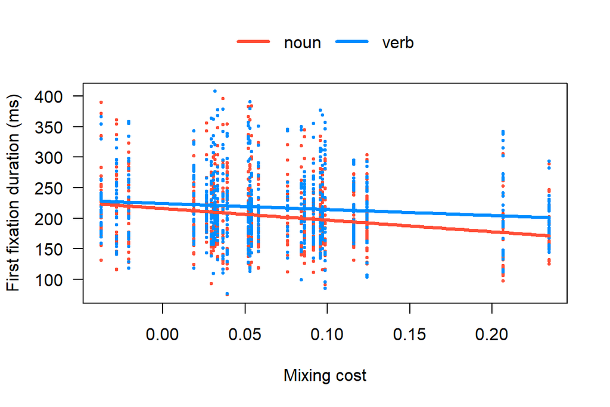

```r
library(visreg)
visreg(mixedModel17, "MixingCost", by = "condition", overlay = T, xlab = "Mixing cost", ylab = "First fixation duration (ms)")
```

Mixing cost refers to mean RTs of non switch trials in a mixed block minus mean RTs of single task trials where no switching takes place.

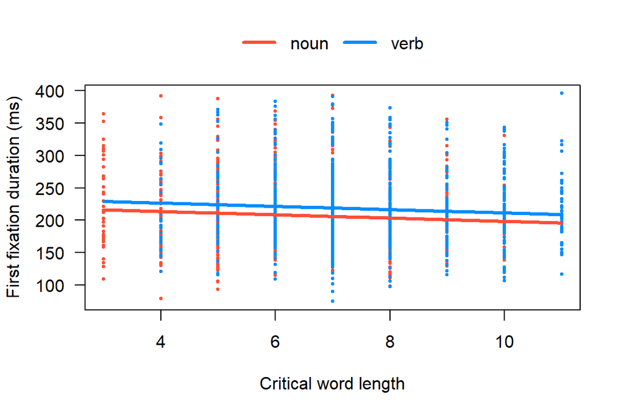

```r
library(visreg)
visreg(mixedModel17, "critical_word_length", by = "condition", overlay = T, xlab = "Critical word length", ylab = "First fixation duration (ms)")
```

## 11.1 Assumptions testing

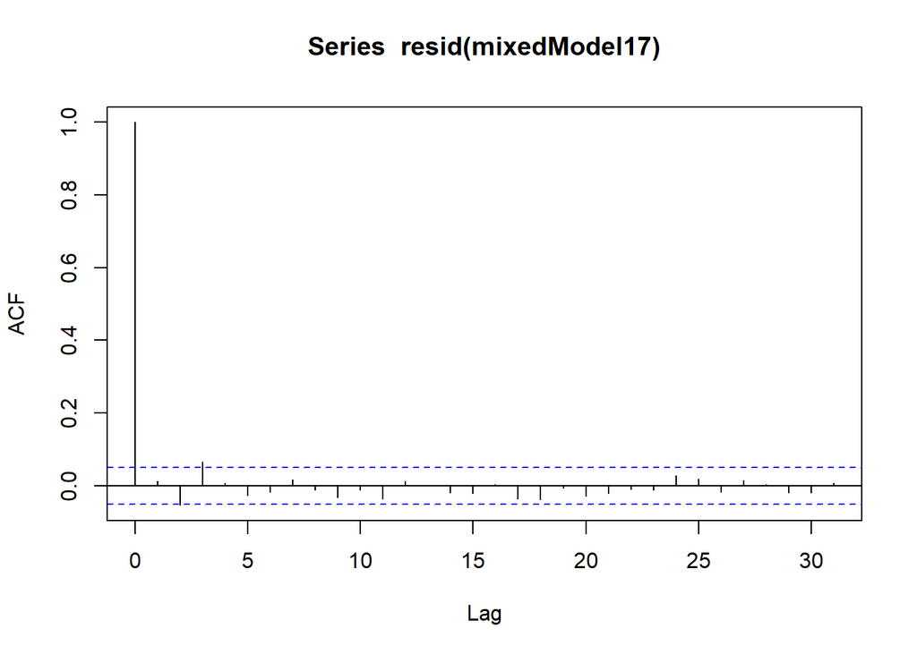

```r
acf(resid(mixedModel17))
```

```r
vif(mixedModel17)
```

```
##            condition           MixingCost critical_word_length
##             2.162992             1.018582             1.051286
## condition:MixingCost
##             2.134724
```

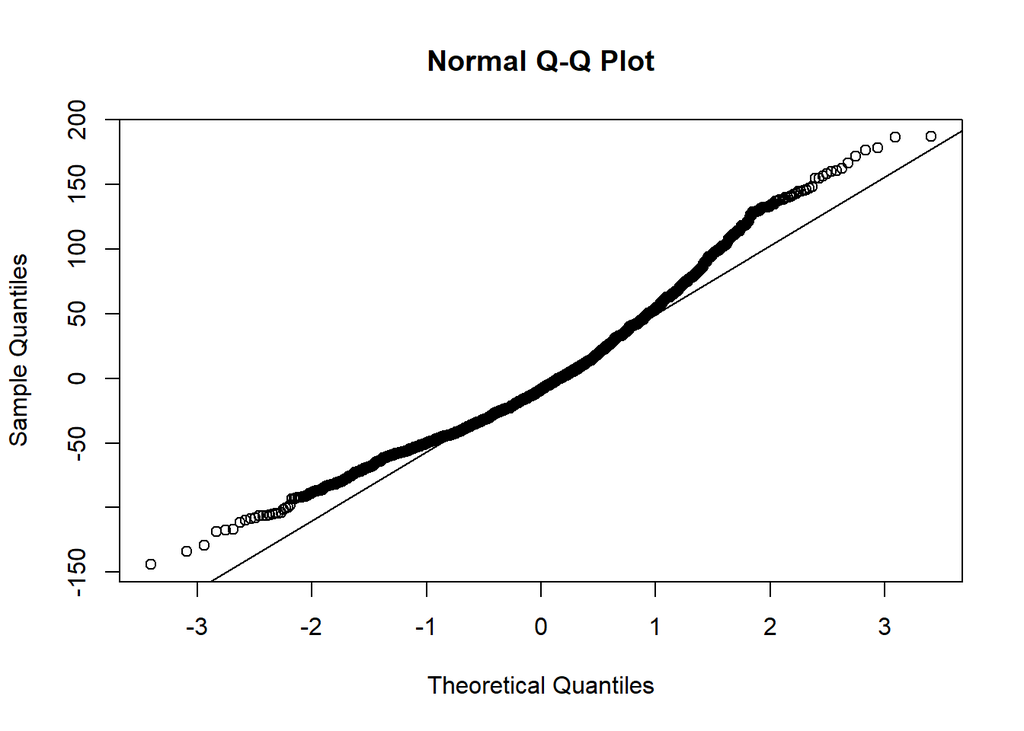

```r
qqnorm(resid(mixedModel17))
qqline(resid(mixedModel17))
```

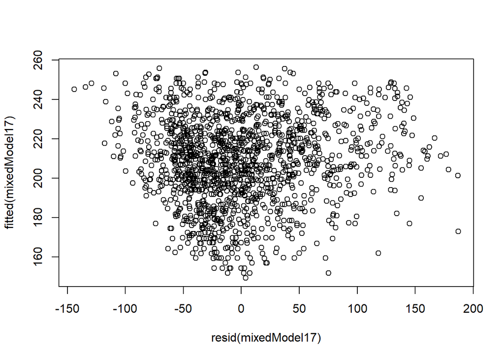

```r
plot(resid(mixedModel17), fitted(mixedModel17))
```

# 12 First pass duration

## 12.1 Linear regression

```r
# Test the null hypothesis that there is no difference in first pass duration between the noun and the denominal verb condition, with condition as fixed effect and random intercept for subjects

mixedmodel1  =lmer(FIRST_PASS_DURATION ~ condition + (1|RECORDING_SESSION_LABEL) , data=Fixdata5)
summary(mixedmodel1)
```

```
## Linear mixed model fit by REML. t-tests use Satterthwaite's method [
## lmerModLmerTest]
## Formula: FIRST_PASS_DURATION ~ condition + (1 | RECORDING_SESSION_LABEL)
##    Data: Fixdata5
##
## REML criterion at convergence: 18431.3
##
## Scaled residuals:
##     Min      1Q  Median      3Q     Max
## -1.8794 -0.7231 -0.2836  0.5525  4.0867
##
## Random effects:
##  Groups                  Name        Variance Std.Dev.
##  RECORDING_SESSION_LABEL (Intercept)   987.1   31.42
##  Residual                            11644.0  107.91
## Number of obs: 1508, groups:  RECORDING_SESSION_LABEL, 26
##
## Fixed effects:
##               Estimate Std. Error       df t value Pr(>|t|)
## (Intercept)    242.968      7.314   33.718  33.220  < 2e-16 ***
## conditionverb   41.016      5.567 1483.082   7.368 2.86e-13 ***
## ---
## Signif. codes:  0 '***' 0.001 '**' 0.01 '*' 0.05 '.' 0.1 ' ' 1
##
## Correlation of Fixed Effects:
##             (Intr)
## conditinvrb -0.378
```

Our hypothesis test shows that verb condition has significantly higher first pass durations compared to the noun condition. Subject variable does not explain much of the variation of the model. Only 8 % of variation is explained through Subjects: 987.1/(987.1 + 11644.0)= 0.08

```r
library(EMAtools)
lme.dscore(mixedmodel1, Fixdata5, type =  "lme4")
```

```
##                      t       df         d
## conditionverb 7.368234 1483.082 0.3826581
```

```r
# Model with item as random intercept

mixedmodel2  =lmer(FIRST_PASS_DURATION ~ condition + (1|item) , data=Fixdata5)
summary(mixedmodel2)
```

```
## Linear mixed model fit by REML. t-tests use Satterthwaite's method [
## lmerModLmerTest]
## Formula: FIRST_PASS_DURATION ~ condition + (1 | item)
##    Data: Fixdata5
##
## REML criterion at convergence: 18458.9
##
## Scaled residuals:
##     Min      1Q  Median      3Q     Max
## -2.2082 -0.7036 -0.2638  0.5050  3.4436
##
## Random effects:
##  Groups   Name        Variance Std.Dev.
##  item     (Intercept)   931     30.51
##  Residual             11681    108.08
## Number of obs: 1508, groups:  item, 68
##
## Fixed effects:
##               Estimate Std. Error      df t value Pr(>|t|)
## (Intercept)    242.058      6.551  64.829  36.951  < 2e-16 ***
## conditionverb   40.584      9.273  65.077   4.377 4.46e-05 ***
## ---
## Signif. codes:  0 '***' 0.001 '**' 0.01 '*' 0.05 '.' 0.1 ' ' 1
##
## Correlation of Fixed Effects:
##             (Intr)
## conditinvrb -0.706
```

Item variable does not explain much of the variation of the model. Only 7 % of variation is explained through items: 931 /(931 + 11681)= 0.07

```r
library(EMAtools)
lme.dscore(mixedmodel2, Fixdata5, type = "lme4")
```

```
##                      t       df       d
## conditionverb 4.376791 65.07654 1.08511
```

```r
anova(mixedmodel1, mixedmodel2)
```

```
## refitting model(s) with ML (instead of REML)
```

```
## Data: Fixdata5
## Models:
## mixedmodel1: FIRST_PASS_DURATION ~ condition + (1 | RECORDING_SESSION_LABEL)
## mixedmodel2: FIRST_PASS_DURATION ~ condition + (1 | item)
##             npar   AIC   BIC  logLik deviance Chisq Df Pr(>Chisq)
## mixedmodel1    4 18450 18472 -9221.1    18442
## mixedmodel2    4 18478 18499 -9235.0    18470     0  0
```

Model 1 is better.

```r
# Add syllale count as a fixed effect

mixedmodel3 <- lmer(FIRST_PASS_DURATION ~ condition + syllable_count + (1 | RECORDING_SESSION_LABEL) , data=Fixdata5)
summary(mixedmodel3)
```

```
## Linear mixed model fit by REML. t-tests use Satterthwaite's method [
## lmerModLmerTest]
## Formula:
## FIRST_PASS_DURATION ~ condition + syllable_count + (1 | RECORDING_SESSION_LABEL)
##    Data: Fixdata5
##
## REML criterion at convergence: 18414.6
##
## Scaled residuals:
##     Min      1Q  Median      3Q     Max
## -1.8069 -0.7260 -0.2699  0.5632  4.0752
##
## Random effects:
##  Groups                  Name        Variance Std.Dev.
##  RECORDING_SESSION_LABEL (Intercept)   993.2   31.52
##  Residual                            11557.6  107.51
## Number of obs: 1508, groups:  RECORDING_SESSION_LABEL, 26
##
## Fixed effects:
##                Estimate Std. Error       df t value Pr(>|t|)
## (Intercept)     216.026     10.688  147.231  20.211  < 2e-16 ***
## conditionverb    37.451      5.641 1481.995   6.639 4.42e-11 ***
## syllable_count   15.112      4.367 1481.086   3.461 0.000554 ***
## ---
## Signif. codes:  0 '***' 0.001 '**' 0.01 '*' 0.05 '.' 0.1 ' ' 1
##
## Correlation of Fixed Effects:
##             (Intr) cndtnv
## conditinvrb -0.120
## syllabl_cnt -0.728 -0.183
```

For every added syllable the first pass duration to the critical words increases with 15.11

```r
library(EMAtools)
lme.dscore(mixedmodel3, Fixdata5, type = "lme4")
```

```
##                       t       df         d
## conditionverb  6.639000 1481.995 0.3449128
## syllable_count 3.460598 1481.086 0.1798420
```

```r
anova(mixedmodel1,mixedmodel3)
```

```
## refitting model(s) with ML (instead of REML)
```

```
## Data: Fixdata5
## Models:
## mixedmodel1: FIRST_PASS_DURATION ~ condition + (1 | RECORDING_SESSION_LABEL)
## mixedmodel3: FIRST_PASS_DURATION ~ condition + syllable_count + (1 | RECORDING_SESSION_LABEL)
##             npar   AIC   BIC  logLik deviance  Chisq Df Pr(>Chisq)
## mixedmodel1    4 18450 18472 -9221.1    18442
## mixedmodel3    5 18440 18467 -9215.1    18430 11.939  1  0.0005497 ***
## ---
## Signif. codes:  0 '***' 0.001 '**' 0.01 '*' 0.05 '.' 0.1 ' ' 1
```

Model 3 with syllable count as a fixed effect significantly improves the model.

```r
# Test the interaction between condition and syllable count

mixedmodel4 <- lmer(FIRST_PASS_DURATION ~ condition * syllable_count  + (1 | RECORDING_SESSION_LABEL) , data=Fixdata5)
summary(mixedmodel4)
```

```
## Linear mixed model fit by REML. t-tests use Satterthwaite's method [
## lmerModLmerTest]
## Formula:
## FIRST_PASS_DURATION ~ condition * syllable_count + (1 | RECORDING_SESSION_LABEL)
##    Data: Fixdata5
##
## REML criterion at convergence: 18391.1
##
## Scaled residuals:
##     Min      1Q  Median      3Q     Max
## -1.9910 -0.7287 -0.2622  0.5542  4.1356
##
## Random effects:
##  Groups                  Name        Variance Std.Dev.
##  RECORDING_SESSION_LABEL (Intercept)  1007     31.73
##  Residual                            11429    106.91
## Number of obs: 1508, groups:  RECORDING_SESSION_LABEL, 26
##
## Fixed effects:
##                              Estimate Std. Error       df t value Pr(>|t|)
## (Intercept)                   248.287     13.175  306.832  18.846  < 2e-16 ***
## conditionverb                 -31.516     17.441 1479.658  -1.807    0.071 .
## syllable_count                 -2.961      6.131 1479.760  -0.483    0.629
## conditionverb:syllable_count   36.261      8.682 1479.570   4.177 3.13e-05 ***
## ---
## Signif. codes:  0 '***' 0.001 '**' 0.01 '*' 0.05 '.' 0.1 ' ' 1
##
## Correlation of Fixed Effects:
##             (Intr) cndtnv syllb_
## conditinvrb -0.586
## syllabl_cnt -0.830  0.627
## cndtnvrb:s_  0.586 -0.947 -0.706
```

```r
library(EMAtools)
lme.dscore(mixedmodel4, Fixdata5, type = "lme4")
```

```
##                                       t       df           d
## conditionverb                -1.8070309 1479.658 -0.09395390
## syllable_count               -0.4829285 1479.760 -0.02510829
## conditionverb:syllable_count  4.1765664 1479.570  0.21716093
```

```r
anova(mixedmodel3, mixedmodel4) # the interaction significantly improves the model
```

```
## refitting model(s) with ML (instead of REML)
```

```
## Data: Fixdata5
## Models:
## mixedmodel3: FIRST_PASS_DURATION ~ condition + syllable_count + (1 | RECORDING_SESSION_LABEL)
## mixedmodel4: FIRST_PASS_DURATION ~ condition * syllable_count + (1 | RECORDING_SESSION_LABEL)
##             npar   AIC   BIC  logLik deviance  Chisq Df Pr(>Chisq)
## mixedmodel3    5 18440 18467 -9215.1    18430
## mixedmodel4    6 18425 18457 -9206.5    18413 17.364  1  3.086e-05 ***
## ---
## Signif. codes:  0 '***' 0.001 '**' 0.01 '*' 0.05 '.' 0.1 ' ' 1
```

Model 4 is better.

```r
# Add critical word length as a fixed effect

mixedmodel5 <- lmer(FIRST_PASS_DURATION ~ condition * syllable_count + critical_word_length  + (1 | RECORDING_SESSION_LABEL) , data = Fixdata5)

summary(mixedmodel5, cor = F)
```

```
## Linear mixed model fit by REML. t-tests use Satterthwaite's method [
## lmerModLmerTest]
## Formula:
## FIRST_PASS_DURATION ~ condition * syllable_count + critical_word_length +
##     (1 | RECORDING_SESSION_LABEL)
##    Data: Fixdata5
##
## REML criterion at convergence: 18372.2
##
## Scaled residuals:
##     Min      1Q  Median      3Q     Max
## -1.8810 -0.7362 -0.2376  0.5253  3.9426
##
## Random effects:
##  Groups                  Name        Variance Std.Dev.
##  RECORDING_SESSION_LABEL (Intercept)  1024     31.99
##  Residual                            11313    106.36
## Number of obs: 1508, groups:  RECORDING_SESSION_LABEL, 26
##
## Fixed effects:
##                              Estimate Std. Error       df t value Pr(>|t|)
## (Intercept)                   224.230     14.469  408.704  15.497  < 2e-16 ***
## conditionverb                 -45.630     17.710 1478.624  -2.577   0.0101 *
## syllable_count                -16.430      6.974 1479.018  -2.356   0.0186 *
## critical_word_length            7.385      1.854 1479.223   3.983 7.13e-05 ***
## conditionverb:syllable_count   40.877      8.715 1478.601   4.690 2.98e-06 ***
## ---
## Signif. codes:  0 '***' 0.001 '**' 0.01 '*' 0.05 '.' 0.1 ' ' 1
```

```r
library(EMAtools)
lme.dscore(mixedmodel5, Fixdata5, type = "lme4")
```

```
##                                      t       df          d
## conditionverb                -2.576577 1478.624 -0.1340122
## syllable_count               -2.355859 1479.018 -0.1225159
## critical_word_length          3.983095 1479.223  0.2071256
## conditionverb:syllable_count  4.690316 1478.601  0.2439532
```

```r
anova(mixedmodel4, mixedmodel5) # adding critical word length as a fixed effect significantly improves the model
```

```
## refitting model(s) with ML (instead of REML)
```

```
## Data: Fixdata5
## Models:
## mixedmodel4: FIRST_PASS_DURATION ~ condition * syllable_count + (1 | RECORDING_SESSION_LABEL)
## mixedmodel5: FIRST_PASS_DURATION ~ condition * syllable_count + critical_word_length + (1 | RECORDING_SESSION_LABEL)
##             npar   AIC   BIC  logLik deviance  Chisq Df Pr(>Chisq)
## mixedmodel4    6 18425 18457 -9206.5    18413
## mixedmodel5    7 18411 18448 -9198.6    18397 15.807  1  7.015e-05 ***
## ---
## Signif. codes:  0 '***' 0.001 '**' 0.01 '*' 0.05 '.' 0.1 ' ' 1
```

```r
# Add aprime as a fixed effect

mixedmodel6 <- lmer(FIRST_PASS_DURATION ~ condition * syllable_count + critical_word_length  + aprime + (1 | RECORDING_SESSION_LABEL) , data = Fixdata5)

summary(mixedmodel6, cor = F)
```

```
## Linear mixed model fit by REML. t-tests use Satterthwaite's method [
## lmerModLmerTest]
## Formula:
## FIRST_PASS_DURATION ~ condition * syllable_count + critical_word_length +
##     aprime + (1 | RECORDING_SESSION_LABEL)
##    Data: Fixdata5
##
## REML criterion at convergence: 18360.8
##
## Scaled residuals:
##     Min      1Q  Median      3Q     Max
## -1.8857 -0.7370 -0.2365  0.5297  3.9455
##
## Random effects:
##  Groups                  Name        Variance Std.Dev.
##  RECORDING_SESSION_LABEL (Intercept)  1003     31.67
##  Residual                            11313    106.36
## Number of obs: 1508, groups:  RECORDING_SESSION_LABEL, 26
##
## Fixed effects:
##                              Estimate Std. Error       df t value Pr(>|t|)
## (Intercept)                   288.016     56.318   33.181   5.114 1.30e-05 ***
## conditionverb                 -45.763     17.710 1478.404  -2.584  0.00986 **
## syllable_count                -16.445      6.974 1478.914  -2.358  0.01850 *
## critical_word_length            7.377      1.854 1479.113   3.979 7.26e-05 ***
## aprime                        -69.620     59.411   29.477  -1.172  0.25064
## conditionverb:syllable_count   40.939      8.715 1478.383   4.697 2.88e-06 ***
## ---
## Signif. codes:  0 '***' 0.001 '**' 0.01 '*' 0.05 '.' 0.1 ' ' 1
```

```r
anova(mixedmodel5, mixedmodel6) # adding aprime does not significantly improve the model
```

```
## refitting model(s) with ML (instead of REML)
```

```
## Data: Fixdata5
## Models:
## mixedmodel5: FIRST_PASS_DURATION ~ condition * syllable_count + critical_word_length + (1 | RECORDING_SESSION_LABEL)
## mixedmodel6: FIRST_PASS_DURATION ~ condition * syllable_count + critical_word_length + aprime + (1 | RECORDING_SESSION_LABEL)
##             npar   AIC   BIC  logLik deviance  Chisq Df Pr(>Chisq)
## mixedmodel5    7 18411 18448 -9198.6    18397
## mixedmodel6    8 18412 18454 -9197.8    18396 1.4404  1     0.2301
```

```r
# Add performance (Flanker scores) as a fixed effect

mixedmodel7 <- lmer(FIRST_PASS_DURATION ~ condition * syllable_count + critical_word_length  + performance + (1 | RECORDING_SESSION_LABEL) , data = Fixdata5)

summary(mixedmodel7, cor = F)
```

```
## Linear mixed model fit by REML. t-tests use Satterthwaite's method [
## lmerModLmerTest]
## Formula:
## FIRST_PASS_DURATION ~ condition * syllable_count + critical_word_length +
##     performance + (1 | RECORDING_SESSION_LABEL)
##    Data: Fixdata5
##
## REML criterion at convergence: 18358.9
##
## Scaled residuals:
##     Min      1Q  Median      3Q     Max
## -1.8811 -0.7349 -0.2371  0.5305  3.9479
##
## Random effects:
##  Groups                  Name        Variance Std.Dev.
##  RECORDING_SESSION_LABEL (Intercept)  1059     32.55
##  Residual                            11313    106.36
## Number of obs: 1508, groups:  RECORDING_SESSION_LABEL, 26
##
## Fixed effects:
##                              Estimate Std. Error       df t value Pr(>|t|)
## (Intercept)                   217.931     18.239   89.998  11.948  < 2e-16 ***
## conditionverb                 -45.637     17.710 1478.660  -2.577   0.0101 *
## syllable_count                -16.416      6.974 1478.973  -2.354   0.0187 *
## critical_word_length            7.381      1.854 1479.151   3.981 7.20e-05 ***
## performance                   152.811    267.644   24.640   0.571   0.5732
## conditionverb:syllable_count   40.884      8.715 1478.639   4.691 2.97e-06 ***
## ---
## Signif. codes:  0 '***' 0.001 '**' 0.01 '*' 0.05 '.' 0.1 ' ' 1
```

```r
anova(mixedmodel5, mixedmodel7) # adding performance does not significantly improve the model
```

```
## refitting model(s) with ML (instead of REML)
```

```
## Data: Fixdata5
## Models:
## mixedmodel5: FIRST_PASS_DURATION ~ condition * syllable_count + critical_word_length + (1 | RECORDING_SESSION_LABEL)
## mixedmodel7: FIRST_PASS_DURATION ~ condition * syllable_count + critical_word_length + performance + (1 | RECORDING_SESSION_LABEL)
##             npar   AIC   BIC  logLik deviance  Chisq Df Pr(>Chisq)
## mixedmodel5    7 18411 18448 -9198.6    18397
## mixedmodel7    8 18413 18455 -9198.4    18397 0.3476  1     0.5555
```

```r
# Add Switching Cost as a fixed effect

mixedmodel8 <- lmer(FIRST_PASS_DURATION ~ condition * syllable_count + critical_word_length  + SwitchingCost + (1 | RECORDING_SESSION_LABEL) , data = Fixdata5)

summary(mixedmodel8, cor = F)
```

```
## Linear mixed model fit by REML. t-tests use Satterthwaite's method [
## lmerModLmerTest]
## Formula:
## FIRST_PASS_DURATION ~ condition * syllable_count + critical_word_length +
##     SwitchingCost + (1 | RECORDING_SESSION_LABEL)
##    Data: Fixdata5
##
## REML criterion at convergence: 18360.4
##
## Scaled residuals:
##     Min      1Q  Median      3Q     Max
## -1.8845 -0.7354 -0.2380  0.5278  3.9476
##
## Random effects:
##  Groups                  Name        Variance Std.Dev.
##  RECORDING_SESSION_LABEL (Intercept)  1072     32.75
##  Residual                            11313    106.36
## Number of obs: 1508, groups:  RECORDING_SESSION_LABEL, 26
##
## Fixed effects:
##                              Estimate Std. Error       df t value Pr(>|t|)
## (Intercept)                   225.239     15.217  247.683  14.802  < 2e-16 ***
## conditionverb                 -45.641     17.710 1478.603  -2.577   0.0101 *
## syllable_count                -16.429      6.974 1478.912  -2.356   0.0186 *
## critical_word_length            7.386      1.854 1479.145   3.984 7.11e-05 ***
## SwitchingCost                 -32.947    148.399   24.185  -0.222   0.8262
## conditionverb:syllable_count   40.886      8.715 1478.581   4.691 2.96e-06 ***
## ---
## Signif. codes:  0 '***' 0.001 '**' 0.01 '*' 0.05 '.' 0.1 ' ' 1
```

```r
anova(mixedmodel5, mixedmodel8) # adding Switching cost does not significantly improve the model
```

```
## refitting model(s) with ML (instead of REML)
```

```
## Data: Fixdata5
## Models:
## mixedmodel5: FIRST_PASS_DURATION ~ condition * syllable_count + critical_word_length + (1 | RECORDING_SESSION_LABEL)
## mixedmodel8: FIRST_PASS_DURATION ~ condition * syllable_count + critical_word_length + SwitchingCost + (1 | RECORDING_SESSION_LABEL)
##             npar   AIC   BIC  logLik deviance  Chisq Df Pr(>Chisq)
## mixedmodel5    7 18411 18448 -9198.6    18397
## mixedmodel8    8 18413 18456 -9198.5    18397 0.0527  1     0.8184
```

```r
# Add Mixing Cost as a fixed effect

mixedmodel9<- lmer(FIRST_PASS_DURATION ~ condition * syllable_count + critical_word_length  + MixingCost + (1 | RECORDING_SESSION_LABEL) , data = Fixdata5)

summary(mixedmodel9, cor = F)
```

```
## Linear mixed model fit by REML. t-tests use Satterthwaite's method [
## lmerModLmerTest]
## Formula:
## FIRST_PASS_DURATION ~ condition * syllable_count + critical_word_length +
##     MixingCost + (1 | RECORDING_SESSION_LABEL)
##    Data: Fixdata5
##
## REML criterion at convergence: 18359.4
##
## Scaled residuals:
##     Min      1Q  Median      3Q     Max
## -1.8668 -0.7345 -0.2379  0.5266  3.9726
##
## Random effects:
##  Groups                  Name        Variance Std.Dev.
##  RECORDING_SESSION_LABEL (Intercept)   993.1   31.51
##  Residual                            11313.3  106.36
## Number of obs: 1508, groups:  RECORDING_SESSION_LABEL, 26
##
## Fixed effects:
##                              Estimate Std. Error       df t value Pr(>|t|)
## (Intercept)                   233.220     16.110  158.378  14.477  < 2e-16 ***
## conditionverb                 -45.597     17.710 1478.518  -2.575   0.0101 *
## syllable_count                -16.413      6.974 1478.922  -2.353   0.0187 *
## critical_word_length            7.388      1.854 1479.127   3.985 7.09e-05 ***
## MixingCost                   -138.945    110.686   23.153  -1.255   0.2219
## conditionverb:syllable_count   40.849      8.715 1478.489   4.687 3.03e-06 ***
## ---
## Signif. codes:  0 '***' 0.001 '**' 0.01 '*' 0.05 '.' 0.1 ' ' 1
```

```r
anova(mixedmodel5, mixedmodel9) # adding Mixing cost does not significantly improve the model
```

```
## refitting model(s) with ML (instead of REML)
```

```
## Data: Fixdata5
## Models:
## mixedmodel5: FIRST_PASS_DURATION ~ condition * syllable_count + critical_word_length + (1 | RECORDING_SESSION_LABEL)
## mixedmodel9: FIRST_PASS_DURATION ~ condition * syllable_count + critical_word_length + MixingCost + (1 | RECORDING_SESSION_LABEL)
##             npar   AIC   BIC  logLik deviance  Chisq Df Pr(>Chisq)
## mixedmodel5    7 18411 18448 -9198.6    18397
## mixedmodel9    8 18412 18454 -9197.7    18396 1.6563  1     0.1981
```

```r
# Add CLIP_Q as a fixed effect

mixedmodel10 <- lmer(FIRST_PASS_DURATION ~ condition * syllable_count + critical_word_length  + CLIP_Q + (1 | RECORDING_SESSION_LABEL) , data = Fixdata5)

summary(mixedmodel10, cor = F)
```

```
## Linear mixed model fit by REML. t-tests use Satterthwaite's method [
## lmerModLmerTest]
## Formula:
## FIRST_PASS_DURATION ~ condition * syllable_count + critical_word_length +
##     CLIP_Q + (1 | RECORDING_SESSION_LABEL)
##    Data: Fixdata5
##
## REML criterion at convergence: 18370.1
##
## Scaled residuals:
##     Min      1Q  Median      3Q     Max
## -1.8871 -0.7354 -0.2345  0.5287  3.9475
##
## Random effects:
##  Groups                  Name        Variance Std.Dev.
##  RECORDING_SESSION_LABEL (Intercept)  1066     32.65
##  Residual                            11313    106.36
## Number of obs: 1508, groups:  RECORDING_SESSION_LABEL, 26
##
## Fixed effects:
##                               Estimate Std. Error        df t value Pr(>|t|)
## (Intercept)                   241.5681    43.0546   28.3988   5.611 5.00e-06
## conditionverb                 -45.6430    17.7097 1478.6300  -2.577   0.0101
## syllable_count                -16.4320     6.9739 1479.0039  -2.356   0.0186
## critical_word_length            7.3842     1.8540 1479.1731   3.983 7.14e-05
## CLIP_Q                         -0.4442     1.0388   23.5171  -0.428   0.6728
## conditionverb:syllable_count   40.8942     8.7151 1478.5950   4.692 2.95e-06
##
## (Intercept)                  ***
## conditionverb                *
## syllable_count               *
## critical_word_length         ***
## CLIP_Q
## conditionverb:syllable_count ***
## ---
## Signif. codes:  0 '***' 0.001 '**' 0.01 '*' 0.05 '.' 0.1 ' ' 1
```

```r
anova(mixedmodel5, mixedmodel10) # adding CLIP_Q  does not significantly improve the model
```

```
## refitting model(s) with ML (instead of REML)
```

```
## Data: Fixdata5
## Models:
## mixedmodel5: FIRST_PASS_DURATION ~ condition * syllable_count + critical_word_length + (1 | RECORDING_SESSION_LABEL)
## mixedmodel10: FIRST_PASS_DURATION ~ condition * syllable_count + critical_word_length + CLIP_Q + (1 | RECORDING_SESSION_LABEL)
##              npar   AIC   BIC  logLik deviance  Chisq Df Pr(>Chisq)
## mixedmodel5     7 18411 18448 -9198.6    18397
## mixedmodel10    8 18413 18456 -9198.5    18397 0.1971  1     0.6571
```

```r
# Add reading as a fixed effect

mixedmodel11 <- lmer(FIRST_PASS_DURATION ~ condition * syllable_count + critical_word_length  + reading + (1 | RECORDING_SESSION_LABEL) , data = Fixdata5)

summary(mixedmodel11, cor = F)
```

```
## Linear mixed model fit by REML. t-tests use Satterthwaite's method [
## lmerModLmerTest]
## Formula:
## FIRST_PASS_DURATION ~ condition * syllable_count + critical_word_length +
##     reading + (1 | RECORDING_SESSION_LABEL)
##    Data: Fixdata5
##
## REML criterion at convergence: 18371.3
##
## Scaled residuals:
##     Min      1Q  Median      3Q     Max
## -1.8785 -0.7335 -0.2385  0.5319  3.9472
##
## Random effects:
##  Groups                  Name        Variance Std.Dev.
##  RECORDING_SESSION_LABEL (Intercept)  1063     32.61
##  Residual                            11313    106.36
## Number of obs: 1508, groups:  RECORDING_SESSION_LABEL, 26
##
## Fixed effects:
##                               Estimate Std. Error        df t value Pr(>|t|)
## (Intercept)                   216.5312    21.3676   58.9496  10.134 1.58e-14
## conditionverb                 -45.6555    17.7097 1478.6375  -2.578   0.0100
## syllable_count                -16.4331     6.9739 1479.0221  -2.356   0.0186
## critical_word_length            7.3899     1.8540 1479.1883   3.986 7.05e-05
## reading                         0.2785     0.5666   24.9862   0.492   0.6273
## conditionverb:syllable_count   40.8922     8.7151 1478.6155   4.692 2.95e-06
##
## (Intercept)                  ***
## conditionverb                *
## syllable_count               *
## critical_word_length         ***
## reading
## conditionverb:syllable_count ***
## ---
## Signif. codes:  0 '***' 0.001 '**' 0.01 '*' 0.05 '.' 0.1 ' ' 1
```

```r
anova(mixedmodel5, mixedmodel11) # adding reading does not significantly improve the model
```

```
## refitting model(s) with ML (instead of REML)
```

```
## Data: Fixdata5
## Models:
## mixedmodel5: FIRST_PASS_DURATION ~ condition * syllable_count + critical_word_length + (1 | RECORDING_SESSION_LABEL)
## mixedmodel11: FIRST_PASS_DURATION ~ condition * syllable_count + critical_word_length + reading + (1 | RECORDING_SESSION_LABEL)
##              npar   AIC   BIC  logLik deviance  Chisq Df Pr(>Chisq)
## mixedmodel5     7 18411 18448 -9198.6    18397
## mixedmodel11    8 18413 18455 -9198.4    18397 0.2572  1      0.612
```

Model 5 is the best.

```r
# Add random slopes

mixedmodel12 <- lmer(FIRST_PASS_DURATION ~ condition * syllable_count + critical_word_length  + (1 + condition| RECORDING_SESSION_LABEL) , data = Fixdata5)

summary(mixedmodel12, cor = F)
```

```
## Linear mixed model fit by REML. t-tests use Satterthwaite's method [
## lmerModLmerTest]
## Formula:
## FIRST_PASS_DURATION ~ condition * syllable_count + critical_word_length +
##     (1 + condition | RECORDING_SESSION_LABEL)
##    Data: Fixdata5
##
## REML criterion at convergence: 18356.8
##
## Scaled residuals:
##     Min      1Q  Median      3Q     Max
## -2.3041 -0.7080 -0.2608  0.5348  3.7759
##
## Random effects:
##  Groups                  Name          Variance Std.Dev. Corr
##  RECORDING_SESSION_LABEL (Intercept)     653.3   25.56
##                          conditionverb   956.2   30.92   0.17
##  Residual                              11081.3  105.27
## Number of obs: 1508, groups:  RECORDING_SESSION_LABEL, 26
##
## Fixed effects:
##                              Estimate Std. Error       df t value Pr(>|t|)
## (Intercept)                   223.998     13.845  441.400  16.178  < 2e-16 ***
## conditionverb                 -46.532     18.560  504.877  -2.507   0.0125 *
## syllable_count                -16.486      6.903 1456.896  -2.388   0.0171 *
## critical_word_length            7.412      1.836 1455.629   4.037 5.68e-05 ***
## conditionverb:syllable_count   41.512      8.630 1455.991   4.810 1.66e-06 ***
## ---
## Signif. codes:  0 '***' 0.001 '**' 0.01 '*' 0.05 '.' 0.1 ' ' 1
```

```r
library(EMAtools)
lme.dscore(mixedmodel12, Fixdata5, type = "lme4")
```

```
##                                      t        df          d
## conditionverb                -2.507141  504.8772 -0.2231597
## syllable_count               -2.388101 1456.8964 -0.1251320
## critical_word_length          4.037500 1455.6290  0.2116495
## conditionverb:syllable_count  4.810166 1455.9915  0.2521220
```

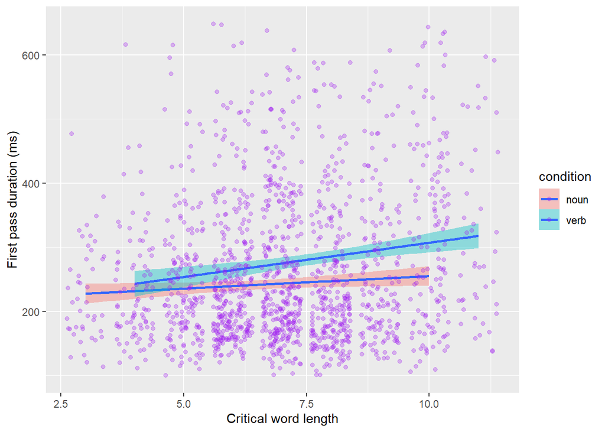

```r
library(ggplot2)

ggplot(data = Fixdata5, mapping = aes(x = critical_word_length, y = FIRST_PASS_DURATION, fill = condition)) +
    geom_smooth(method = "lm") +  xlab("Critical word length") +
  geom_jitter(alpha = 0.3, color = "purple")+
ylab("First pass duration (ms)")
```

```r
# Marginal R2 provides the variance explained only by fixed effects and conditional R2 provides the variance explained by the entire model, i.e., both fixed effects and random effects.
library(MuMIn)
r.squaredGLMM(mixedmodel12)
```

```
##             R2m       R2c
## [1,] 0.05966134 0.1557945
```

## 12.2 Assumptions testing

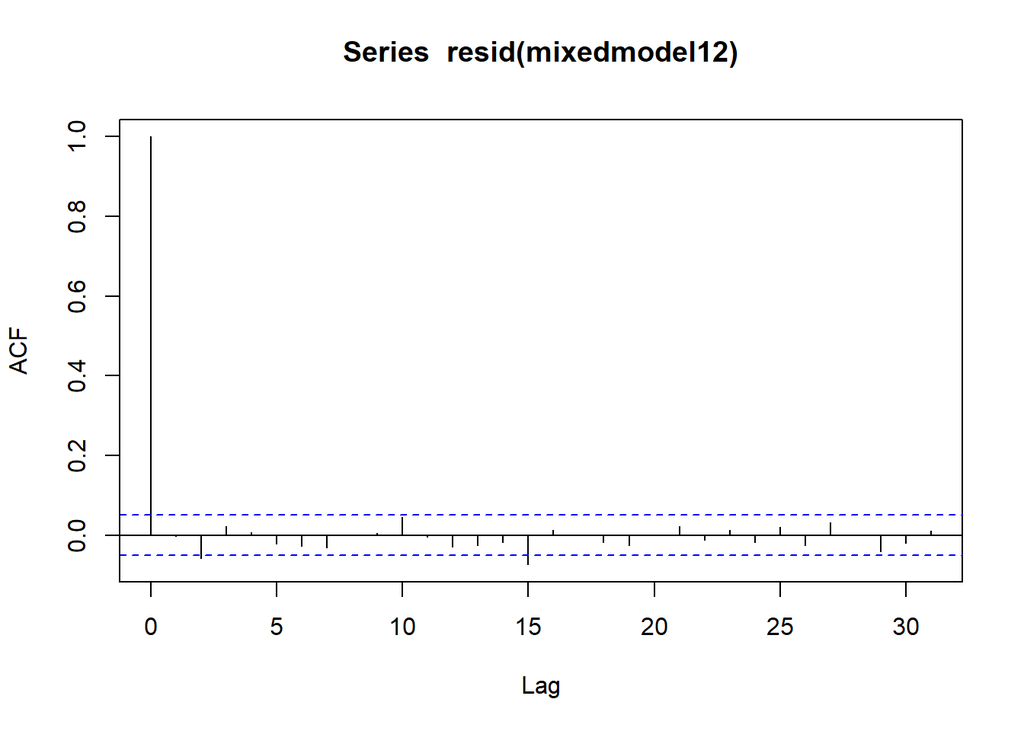

```r
acf(resid(mixedmodel12))
```

```r
vif(mixedmodel12)
```

```
##                condition           syllable_count     critical_word_length
##                 5.170392                 2.644189                 1.497961
## condition:syllable_count
##                 6.582469
```

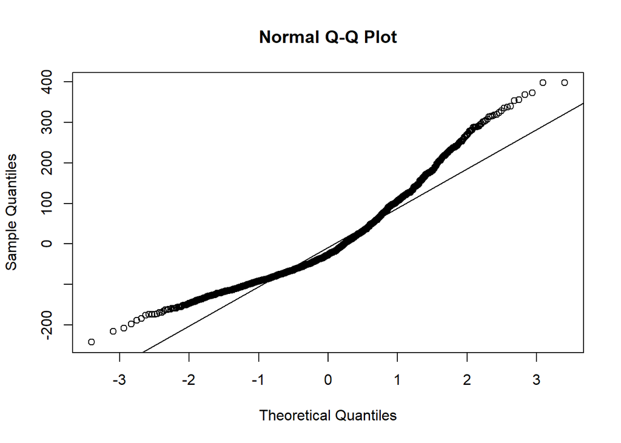

```r
qqnorm(resid(mixedmodel12))
qqline(resid(mixedmodel12))
```

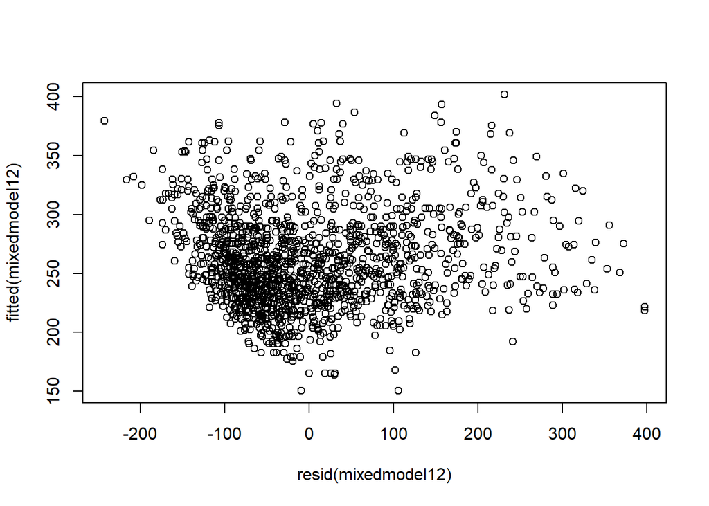

```r
plot(resid(mixedmodel12), fitted(mixedmodel12))
```

## 12.3 Model criticism

The quantile-quantile-plot shows some problems at the tails, so model criticism is needed. We employ model criticism by removing the data points which are problematic for the model.

```r
library(lmerTest)
dat3 <- Fixdata5[abs(scale(resid(mixedmodel12))) < 2.5, ]
(1 - (nrow(dat3))/nrow(Fixdata5)) * 100
```

```
## [1] 2.519894
```

```r
mixedmodel12.v2 <- lmer(FIRST_PASS_DURATION ~ condition * syllable_count + critical_word_length  + (1 | RECORDING_SESSION_LABEL) ,data = dat3)
summary(mixedmodel12.v2)
```

```
## Linear mixed model fit by REML. t-tests use Satterthwaite's method [
## lmerModLmerTest]
## Formula:
## FIRST_PASS_DURATION ~ condition * syllable_count + critical_word_length +
##     (1 | RECORDING_SESSION_LABEL)
##    Data: dat3
##
## REML criterion at convergence: 17567
##
## Scaled residuals:
##     Min      1Q  Median      3Q     Max
## -2.0457 -0.7392 -0.2208  0.5704  2.9929
##
## Random effects:
##  Groups                  Name        Variance Std.Dev.
##  RECORDING_SESSION_LABEL (Intercept) 1146     33.86
##  Residual                            8912     94.40
## Number of obs: 1470, groups:  RECORDING_SESSION_LABEL, 26
##
## Fixed effects:
##                              Estimate Std. Error       df t value Pr(>|t|)
## (Intercept)                   218.464     13.434  287.604  16.262  < 2e-16 ***
## conditionverb                 -30.248     15.896 1440.965  -1.903   0.0573 .
## syllable_count                -16.281      6.287 1441.369  -2.590   0.0097 **
## critical_word_length            6.988      1.674 1441.493   4.176 3.15e-05 ***
## conditionverb:syllable_count   33.247      7.838 1440.822   4.242 2.36e-05 ***
## ---
## Signif. codes:  0 '***' 0.001 '**' 0.01 '*' 0.05 '.' 0.1 ' ' 1
##
## Correlation of Fixed Effects:
##             (Intr) cndtnv syllb_ crtc__
## conditinvrb -0.420
## syllabl_cnt -0.436  0.637
## crtcl_wrd_l -0.400 -0.208 -0.492
## cndtnvrb:s_  0.452 -0.946 -0.677  0.140
```

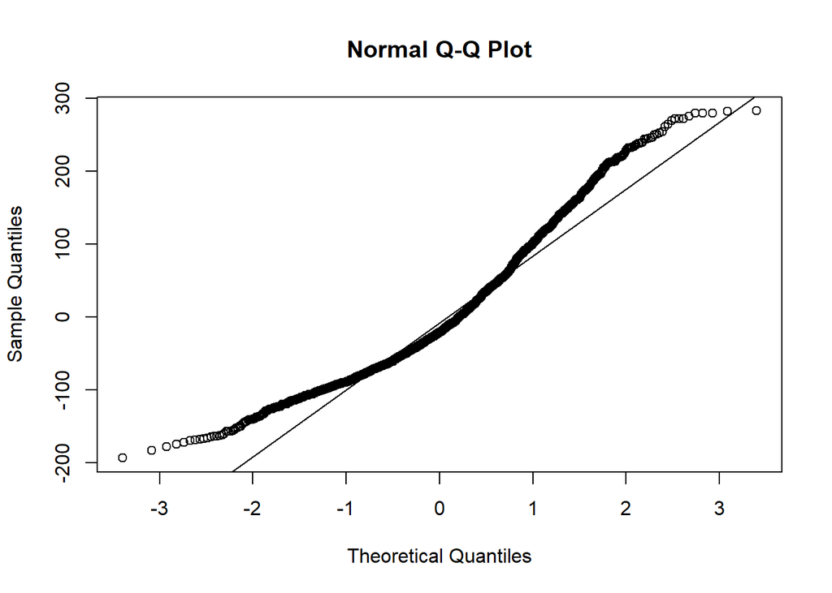

```r
qqnorm(resid(mixedmodel12.v2))
qqline(resid(mixedmodel12.v2))
```

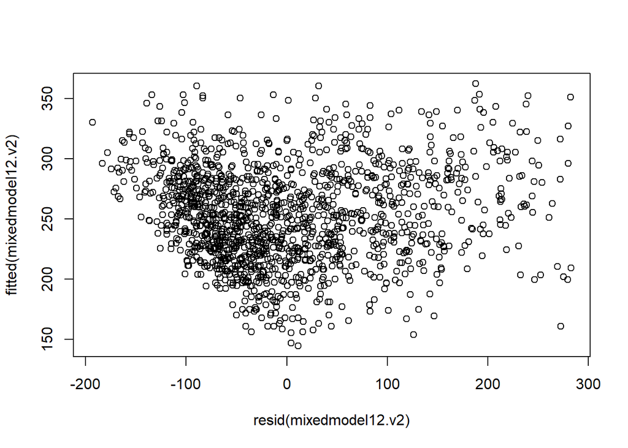

```r
plot(resid(mixedmodel12.v2), fitted(mixedmodel12.v2))
```

```r
library(EMAtools)
lme.dscore(mixedmodel12.v2, Fixdata5, type =  "lme4")
```

[output not shown]

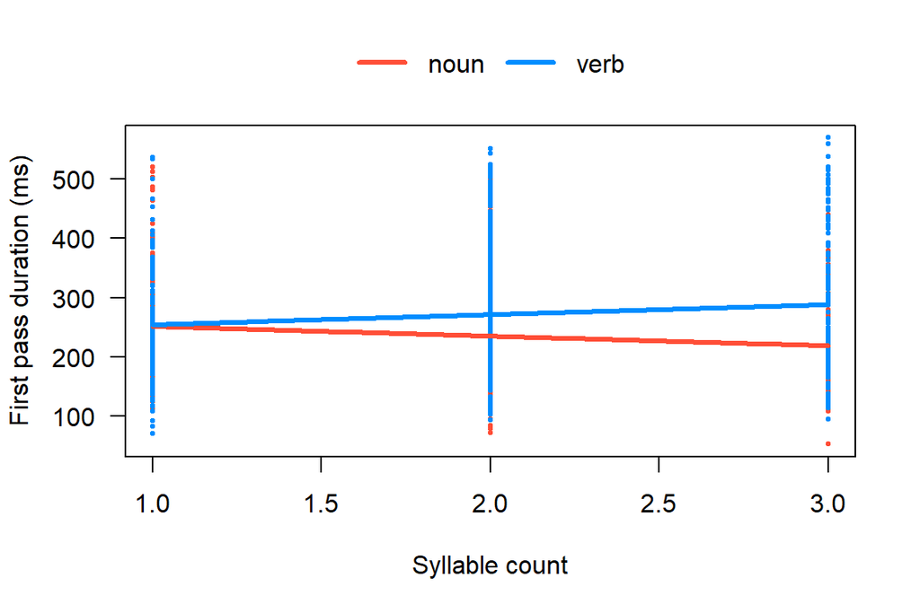

```r
visreg(mixedmodel12.v2, "syllable_count", by = "condition", overlay = T, xlab = "Syllable count", ylab = "First pass duration (ms)")
```

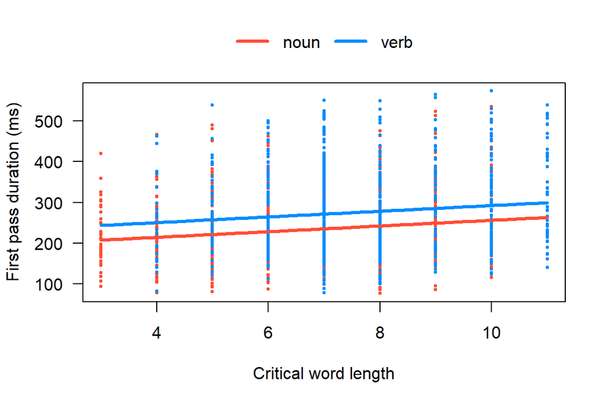

```r
visreg(mixedmodel12.v2, "critical_word_length", by = "condition", overlay = T, xlab = "Critical word length", ylab = "First pass duration (ms)")
```

# 13 Total pass duration

```r
# Test the null hypothesis that there is no difference in the total reading time between the noun and the denominal verb condition, with condition as fixed effect and random intercepts for subjects

model1  =lmer(TOTAL_DURATION ~ condition + (1|RECORDING_SESSION_LABEL) , data=Fixdata5)
summary( model1)
```

```
## Linear mixed model fit by REML. t-tests use Satterthwaite's method [
## lmerModLmerTest]
## Formula: TOTAL_DURATION ~ condition + (1 | RECORDING_SESSION_LABEL)
##    Data: Fixdata5
##
## REML criterion at convergence: 22822.7
##
## Scaled residuals:
##     Min      1Q  Median      3Q     Max
## -2.1098 -0.7206 -0.1513  0.6117  3.9166
##
## Random effects:
##  Groups                  Name        Variance Std.Dev.
##  RECORDING_SESSION_LABEL (Intercept)  40751   201.9
##  Residual                            212481   461.0
## Number of obs: 1508, groups:  RECORDING_SESSION_LABEL, 26
##
## Fixed effects:
##               Estimate Std. Error      df t value Pr(>|t|)
## (Intercept)     727.91      43.03   28.97   16.92   <2e-16 ***
## conditionverb   326.83      23.78 1481.93   13.74   <2e-16 ***
## ---
## Signif. codes:  0 '***' 0.001 '**' 0.01 '*' 0.05 '.' 0.1 ' ' 1
##
## Correlation of Fixed Effects:
##             (Intr)
## conditinvrb -0.274
```

```r
library(EMAtools)
lme.dscore(model1, Fixdata5, type = "lme4")
```

```
##                      t       df         d
## conditionverb 13.74132 1481.932 0.7139113
```

Our hypothesis test shows that the denominal verb condition has significantly longer total reading times compared to the noun condition.

Subject variable does not explain much of the variation of the model. Only 16 % of variation is explained through Subjects: 40751/(40751 + 212481)= 0.16

```r
# Random intercept for item

library(lmerTest)
model2=lmer(TOTAL_DURATION ~ condition + (1|item) , data=Fixdata5)
summary(model2)
```

```
## Linear mixed model fit by REML. t-tests use Satterthwaite's method [
## lmerModLmerTest]
## Formula: TOTAL_DURATION ~ condition + (1 | item)
##    Data: Fixdata5
##
## REML criterion at convergence: 22938.1
##
## Scaled residuals:
##     Min      1Q  Median      3Q     Max
## -2.3623 -0.7230 -0.1168  0.6254  3.4462
##
## Random effects:
##  Groups   Name        Variance Std.Dev.
##  item     (Intercept)  25664   160.2
##  Residual             226274   475.7
## Number of obs: 1508, groups:  item, 68
##
## Fixed effects:
##               Estimate Std. Error     df t value Pr(>|t|)
## (Intercept)     744.03      32.50  63.36  22.896  < 2e-16 ***
## conditionverb   324.71      45.99  63.55   7.061  1.5e-09 ***
## ---
## Signif. codes:  0 '***' 0.001 '**' 0.01 '*' 0.05 '.' 0.1 ' ' 1
##
## Correlation of Fixed Effects:
##             (Intr)
## conditinvrb -0.707
```

Item variable does not explain much of the variation of the model. Only 10 % of variation is explained through items: 25664/(25664 + 226274)= 0.10

```r
library(EMAtools)
lme.dscore(model2, Fixdata5, type = "lme4")
```

```
##                      t       df        d
## conditionverb 7.060826 63.54791 1.771474
```

```r
anova(model1, model2)
```

```
## refitting model(s) with ML (instead of REML)
```

```
## Data: Fixdata5
## Models:
## model1: TOTAL_DURATION ~ condition + (1 | RECORDING_SESSION_LABEL)
## model2: TOTAL_DURATION ~ condition + (1 | item)
##        npar   AIC   BIC logLik deviance Chisq Df Pr(>Chisq)
## model1    4 22848 22869 -11420    22840
## model2    4 22964 22985 -11478    22956     0  0
```

Model 1 is better.

```r
# Add fixed effect for syllable count

model3 <- lmer(TOTAL_DURATION ~ condition + syllable_count + (1 | RECORDING_SESSION_LABEL) , data=Fixdata5)
summary(model3)
```

```
## Linear mixed model fit by REML. t-tests use Satterthwaite's method [
## lmerModLmerTest]
## Formula:
## TOTAL_DURATION ~ condition + syllable_count + (1 | RECORDING_SESSION_LABEL)
##    Data: Fixdata5
##
## REML criterion at convergence: 22803.1
##
## Scaled residuals:
##     Min      1Q  Median      3Q     Max
## -2.2105 -0.7211 -0.1464  0.5944  3.9020
##
## Random effects:
##  Groups                  Name        Variance Std.Dev.
##  RECORDING_SESSION_LABEL (Intercept)  40688   201.7
##  Residual                            210932   459.3
## Number of obs: 1508, groups:  RECORDING_SESSION_LABEL, 26
##
## Fixed effects:
##                Estimate Std. Error      df t value Pr(>|t|)
## (Intercept)      613.00      54.34   73.38  11.280  < 2e-16 ***
## conditionverb    311.61      24.10 1480.89  12.928  < 2e-16 ***
## syllable_count    64.45      18.66 1480.41   3.454 0.000568 ***
## ---
## Signif. codes:  0 '***' 0.001 '**' 0.01 '*' 0.05 '.' 0.1 ' ' 1
##
## Correlation of Fixed Effects:
##             (Intr) cndtnv
## conditinvrb -0.101
## syllabl_cnt -0.612 -0.183
```

The effect of syllable count is significant (p<0.001). The model direction of the effect is a positive one: with every added syllable, total reading duration is expected to increase with a value of 64.45.

```r
library(EMAtools)
lme.dscore(model3, Fixdata5, type = "lme4")
```

```
##                        t       df         d
## conditionverb  12.928225 1480.888 0.6719048
## syllable_count  3.454167 1480.412 0.1795486
```

```r
anova(model1,model3) # adding syllable count as fixed effect significantly improved the model
```

```
## refitting model(s) with ML (instead of REML)
```

```
## Data: Fixdata5
## Models:
## model1: TOTAL_DURATION ~ condition + (1 | RECORDING_SESSION_LABEL)
## model3: TOTAL_DURATION ~ condition + syllable_count + (1 | RECORDING_SESSION_LABEL)
##        npar   AIC   BIC logLik deviance  Chisq Df Pr(>Chisq)
## model1    4 22848 22869 -11420    22840
## model3    5 22838 22865 -11414    22828 11.902  1  0.0005608 ***
## ---
## Signif. codes:  0 '***' 0.001 '**' 0.01 '*' 0.05 '.' 0.1 ' ' 1
```

```r
# Add interaction between condition and syllable count

model4 <- lmer(TOTAL_DURATION ~ condition * syllable_count + (1 | RECORDING_SESSION_LABEL) , data=Fixdata5)
summary(model4)
```

```
## Linear mixed model fit by REML. t-tests use Satterthwaite's method [
## lmerModLmerTest]
## Formula:
## TOTAL_DURATION ~ condition * syllable_count + (1 | RECORDING_SESSION_LABEL)
##    Data: Fixdata5
##
## REML criterion at convergence: 22786.9
##
## Scaled residuals:
##     Min      1Q  Median      3Q     Max
## -2.3196 -0.7111 -0.1378  0.5990  3.9337
##
## Random effects:
##  Groups                  Name        Variance Std.Dev.
##  RECORDING_SESSION_LABEL (Intercept)  40606   201.5
##  Residual                            210057   458.3
## Number of obs: 1508, groups:  RECORDING_SESSION_LABEL, 26
##
## Fixed effects:
##                              Estimate Std. Error      df t value Pr(>|t|)
## (Intercept)                    701.96      63.57  134.96  11.042   <2e-16 ***
## conditionverb                  121.41      74.78 1479.21   1.624   0.1047
## syllable_count                  14.60      26.28 1479.27   0.556   0.5786
## conditionverb:syllable_count   100.00      37.22 1479.16   2.686   0.0073 **
## ---
## Signif. codes:  0 '***' 0.001 '**' 0.01 '*' 0.05 '.' 0.1 ' ' 1
##
## Correlation of Fixed Effects:
##             (Intr) cndtnv syllb_
## conditinvrb -0.521
## syllabl_cnt -0.738  0.627
## cndtnvrb:s_  0.521 -0.947 -0.706
```

```r
library(EMAtools)
lme.dscore(model4, Fixdata5, type = "lme4")
```

```
##                                      t       df          d
## conditionverb                1.6236650 1479.210 0.08443287
## syllable_count               0.5555735 1479.266 0.02889006
## conditionverb:syllable_count 2.6864469 1479.160 0.13970135
```

```r
anova(model3, model4) # adding the interaction significantly improves the model
```

```
## refitting model(s) with ML (instead of REML)
```

```
## Data: Fixdata5
## Models:
## model3: TOTAL_DURATION ~ condition + syllable_count + (1 | RECORDING_SESSION_LABEL)
## model4: TOTAL_DURATION ~ condition * syllable_count + (1 | RECORDING_SESSION_LABEL)
##        npar   AIC   BIC logLik deviance  Chisq Df Pr(>Chisq)
## model3    5 22838 22865 -11414    22828
## model4    6 22833 22865 -11410    22821 7.2163  1   0.007224 **
## ---
## Signif. codes:  0 '***' 0.001 '**' 0.01 '*' 0.05 '.' 0.1 ' ' 1
```

Model 4 is better.

```r
# Add fixed effect for critical word length

model5 <- lmer(TOTAL_DURATION ~ condition * syllable_count + critical_word_length + (1 | RECORDING_SESSION_LABEL) , data=Fixdata5)
summary(model5)
```

```
## Linear mixed model fit by REML. t-tests use Satterthwaite's method [
## lmerModLmerTest]
## Formula: TOTAL_DURATION ~ condition * syllable_count + critical_word_length +
##     (1 | RECORDING_SESSION_LABEL)
##    Data: Fixdata5
##
## REML criterion at convergence: 22712.9
##
## Scaled residuals:
##     Min      1Q  Median      3Q     Max
## -2.5024 -0.7075 -0.1197  0.5889  3.5815
##
## Random effects:
##  Groups                  Name        Variance Std.Dev.
##  RECORDING_SESSION_LABEL (Intercept)  41471   203.6
##  Residual                            200704   448.0
## Number of obs: 1508, groups:  RECORDING_SESSION_LABEL, 26
##
## Fixed effects:
##                              Estimate Std. Error       df t value Pr(>|t|)
## (Intercept)                   489.632     67.910  168.002   7.210 1.82e-11 ***
## conditionverb                  -2.933     74.600 1478.186  -0.039 0.968643
## syllable_count               -104.170     29.378 1478.377  -3.546 0.000403 ***
## critical_word_length           65.125      7.810 1478.473   8.339  < 2e-16 ***
## conditionverb:syllable_count  140.639     36.711 1478.172   3.831 0.000133 ***
## ---
## Signif. codes:  0 '***' 0.001 '**' 0.01 '*' 0.05 '.' 0.1 ' ' 1
##
## Correlation of Fixed Effects:
##             (Intr) cndtnv syllb_ crtc__
## conditinvrb -0.392
## syllabl_cnt -0.409  0.634
## crtcl_wrd_l -0.375 -0.200 -0.485
## cndtnvrb:s_  0.423 -0.946 -0.676  0.133
```

```r
library(EMAtools)
lme.dscore(model5, Fixdata5, type = "lme4")
```

```
##                                        t       df            d
## conditionverb                -0.03931701 1478.186 -0.002045248
## syllable_count               -3.54590193 1478.377 -0.184443843
## critical_word_length          8.33851706 1478.473  0.433722617
## conditionverb:syllable_count  3.83098430 1478.172  0.199286486
```

The effect of critical word length is significant (p<0.001). The model direction of the effect is a positive one: with every added character, total reading duration of the critical word is expected to increase with a value of 65.12.

```r
anova(model4, model5) # adding critical word length as a fixed effect significantly improved the model.
```

```
## refitting model(s) with ML (instead of REML)
```

```
## Data: Fixdata5
## Models:
## model4: TOTAL_DURATION ~ condition * syllable_count + (1 | RECORDING_SESSION_LABEL)
## model5: TOTAL_DURATION ~ condition * syllable_count + critical_word_length + (1 | RECORDING_SESSION_LABEL)
##        npar   AIC   BIC logLik deviance  Chisq Df Pr(>Chisq)
## model4    6 22833 22865 -11410    22821
## model5    7 22767 22804 -11376    22753 68.094  1  < 2.2e-16 ***
## ---
## Signif. codes:  0 '***' 0.001 '**' 0.01 '*' 0.05 '.' 0.1 ' ' 1
```

Model 5 is better.

```r
# Add a random slope for condition

model6 <- lmer(TOTAL_DURATION ~ condition * syllable_count + critical_word_length + (1 + condition| RECORDING_SESSION_LABEL) , data=Fixdata5)
summary(model6)
```

```
## Linear mixed model fit by REML. t-tests use Satterthwaite's method [
## lmerModLmerTest]
## Formula: TOTAL_DURATION ~ condition * syllable_count + critical_word_length +
##     (1 + condition | RECORDING_SESSION_LABEL)
##    Data: Fixdata5
##
## REML criterion at convergence: 22683.7
##
## Scaled residuals:
##     Min      1Q  Median      3Q     Max
## -2.5310 -0.6967 -0.1265  0.5809  3.6624
##
## Random effects:
##  Groups                  Name          Variance Std.Dev. Corr
##  RECORDING_SESSION_LABEL (Intercept)    26971   164.2
##                          conditionverb  28476   168.7    0.26
##  Residual                              193991   440.4
## Number of obs: 1508, groups:  RECORDING_SESSION_LABEL, 26
##
## Fixed effects:
##                              Estimate Std. Error       df t value Pr(>|t|)
## (Intercept)                   491.870     62.894  215.356   7.821 2.32e-13 ***
## conditionverb                 -12.944     80.532  341.385  -0.161  0.87240
## syllable_count               -104.952     28.892 1457.778  -3.633  0.00029 ***
## critical_word_length           65.743      7.683 1456.850   8.557  < 2e-16 ***
## conditionverb:syllable_count  141.542     36.116 1457.344   3.919 9.30e-05 ***
## ---
## Signif. codes:  0 '***' 0.001 '**' 0.01 '*' 0.05 '.' 0.1 ' ' 1
##
## Correlation of Fixed Effects:
##             (Intr) cndtnv syllb_ crtc__
## conditinvrb -0.325
## syllabl_cnt -0.434  0.578
## crtcl_wrd_l -0.398 -0.182 -0.485
## cndtnvrb:s_  0.448 -0.862 -0.676  0.133
```

```r
lme.dscore(model6, Fixdata5, type = "lme4")
```

```
##                                       t        df           d
## conditionverb                -0.1607328  341.3849 -0.01739852
## syllable_count               -3.6325542 1457.7782 -0.19028141
## critical_word_length          8.5574644 1456.8500  0.44840215
## conditionverb:syllable_count  3.9190718 1457.3436  0.20532046
```

```r
anova(model5, model6) # adding the random slope significantly improved the model
```

```
## refitting model(s) with ML (instead of REML)
```

```
## Data: Fixdata5
## Models:
## model5: TOTAL_DURATION ~ condition * syllable_count + critical_word_length + (1 | RECORDING_SESSION_LABEL)
## model6: TOTAL_DURATION ~ condition * syllable_count + critical_word_length + (1 + condition | RECORDING_SESSION_LABEL)
##        npar   AIC   BIC logLik deviance  Chisq Df Pr(>Chisq)
## model5    7 22767 22804 -11376    22753
## model6    9 22742 22790 -11362    22724 28.499  2   6.48e-07 ***
## ---
## Signif. codes:  0 '***' 0.001 '**' 0.01 '*' 0.05 '.' 0.1 ' ' 1
```

Model 6 is better.

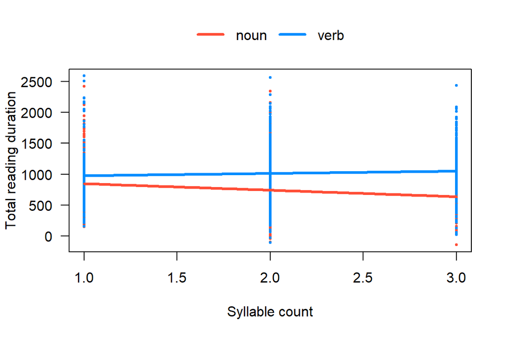

```r
visreg(model6, "syllable_count", by = "condition", overlay = T, xlab = "Syllable count", ylab = "Total reading duration")
```

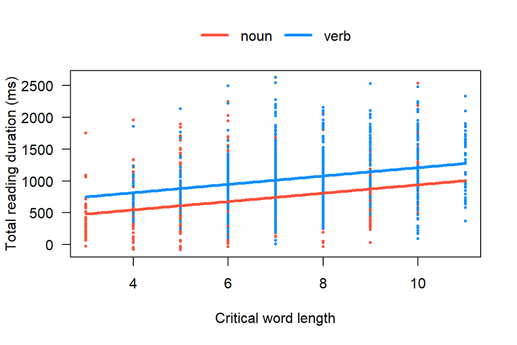

```r
visreg(model6, "critical_word_length", by = "condition", overlay = T, xlab = "Critical word length", ylab = "Total reading duration (ms)")
```

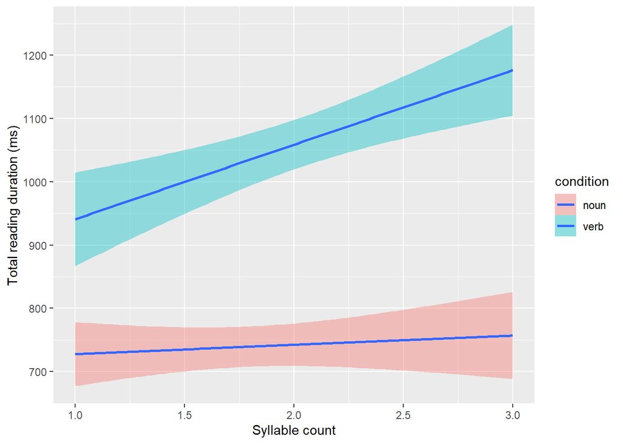

```r
library(ggplot2)

ggplot(data = Fixdata5, mapping = aes(x = syllable_count, y = TOTAL_DURATION, fill = condition)) +
    geom_smooth(method = "lm") +  xlab("Syllable count") +
ylab("Total reading duration (ms)")
```

```r
# Add aprime as a fixed effect
model7 <- lmer(TOTAL_DURATION ~ condition * syllable_count  + critical_word_length + aprime + (1 + condition | RECORDING_SESSION_LABEL) , data = Fixdata5)

summary(model7, cor = F)
```

```
## Linear mixed model fit by REML. t-tests use Satterthwaite's method [
## lmerModLmerTest]
## Formula: TOTAL_DURATION ~ condition * syllable_count + critical_word_length +
##     aprime + (1 + condition | RECORDING_SESSION_LABEL)
##    Data: Fixdata5
##
## REML criterion at convergence: 22668.2
##
## Scaled residuals:
##     Min      1Q  Median      3Q     Max
## -2.5301 -0.6977 -0.1297  0.5866  3.6602
##
## Random effects:
##  Groups                  Name          Variance Std.Dev. Corr
##  RECORDING_SESSION_LABEL (Intercept)    25522   159.8
##                          conditionverb  27944   167.2    0.23
##  Residual                              194014   440.5
## Number of obs: 1508, groups:  RECORDING_SESSION_LABEL, 26
##
## Fixed effects:
##                              Estimate Std. Error       df t value Pr(>|t|)
## (Intercept)                    61.603    291.742   32.933   0.211   0.8341
## conditionverb                 -11.175     80.418  348.097  -0.139   0.8896
## syllable_count               -104.723     28.894 1457.599  -3.624   0.0003 ***
## critical_word_length           65.743      7.683 1456.674   8.557  < 2e-16 ***
## aprime                        469.587    310.939   30.507   1.510   0.1413
## conditionverb:syllable_count  141.317     36.119 1457.136   3.913 9.55e-05 ***
## ---
## Signif. codes:  0 '***' 0.001 '**' 0.01 '*' 0.05 '.' 0.1 ' ' 1
```

```r
library(EMAtools)
lme.dscore(model7, Fixdata5, type = "lme4")
```

```
##                                       t         df           d
## conditionverb                -0.1389615  348.09663 -0.01489617
## syllable_count               -3.6243751 1457.59893 -0.18986465
## critical_word_length          8.5569842 1456.67352  0.44840414
## aprime                        1.5102231   30.50724  0.54685178
## conditionverb:syllable_count  3.9125621 1457.13631  0.20499400
```

```r
anova(model7, model6) # adding aprime as a fixed effect did not significantly improved the model
```

```
## refitting model(s) with ML (instead of REML)
```

```
## Data: Fixdata5
## Models:
## model6: TOTAL_DURATION ~ condition * syllable_count + critical_word_length + (1 + condition | RECORDING_SESSION_LABEL)
## model7: TOTAL_DURATION ~ condition * syllable_count + critical_word_length + aprime + (1 + condition | RECORDING_SESSION_LABEL)
##        npar   AIC   BIC logLik deviance  Chisq Df Pr(>Chisq)
## model6    9 22742 22790 -11362    22724
## model7   10 22742 22795 -11361    22722 2.3471  1     0.1255
```

Model 6 is better.

```r
# Add performance as a fixed effect
model8 <- lmer(TOTAL_DURATION ~ condition * syllable_count  + critical_word_length + performance + (1 + condition | RECORDING_SESSION_LABEL) , data = Fixdata5)

summary(model8, cor = F)
```

```
## Linear mixed model fit by REML. t-tests use Satterthwaite's method [
## lmerModLmerTest]
## Formula: TOTAL_DURATION ~ condition * syllable_count + critical_word_length +
##     performance + (1 + condition | RECORDING_SESSION_LABEL)
##    Data: Fixdata5
##
## REML criterion at convergence: 22665.3
##
## Scaled residuals:
##     Min      1Q  Median      3Q     Max
## -2.5268 -0.7018 -0.1256  0.5809  3.6590
##
## Random effects:
##  Groups                  Name          Variance Std.Dev. Corr
##  RECORDING_SESSION_LABEL (Intercept)    25653   160.2
##                          conditionverb  28258   168.1    0.18
##  Residual                              193988   440.4
## Number of obs: 1508, groups:  RECORDING_SESSION_LABEL, 26
##
## Fixed effects:
##                               Estimate Std. Error        df t value Pr(>|t|)
## (Intercept)                    578.071     84.033    62.895   6.879 3.27e-09
## conditionverb                  -12.783     80.482   344.230  -0.159 0.873899
## syllable_count                -105.057     28.893  1457.694  -3.636 0.000286
## critical_word_length            65.731      7.683  1456.885   8.556  < 2e-16
## performance                  -2078.716   1357.710    25.056  -1.531 0.138287
## conditionverb:syllable_count   141.703     36.117  1457.327   3.923 9.13e-05
##
## (Intercept)                  ***
## conditionverb
## syllable_count               ***
## critical_word_length         ***
## performance
## conditionverb:syllable_count ***
## ---
## Signif. codes:  0 '***' 0.001 '**' 0.01 '*' 0.05 '.' 0.1 ' ' 1
```

```r
library(EMAtools)
lme.dscore(model8, Fixdata5, type = "lme4")
```

```
##                                       t        df           d
## conditionverb                -0.1588264  344.2296 -0.01712098
## syllable_count               -3.6360955 1457.6939 -0.19047243
## critical_word_length          8.5557796 1456.8851  0.44830846
## performance                  -1.5310457   25.0560 -0.61173347
## conditionverb:syllable_count  3.9234699 1457.3268  0.20555206
```

```r
anova(model6,model8) # adding performance as a fixed effect did not significantly improved the model
```

```
## refitting model(s) with ML (instead of REML)
```

```
## Data: Fixdata5
## Models:
## model6: TOTAL_DURATION ~ condition * syllable_count + critical_word_length + (1 + condition | RECORDING_SESSION_LABEL)
## model8: TOTAL_DURATION ~ condition * syllable_count + critical_word_length + performance + (1 + condition | RECORDING_SESSION_LABEL)
##        npar   AIC   BIC logLik deviance  Chisq Df Pr(>Chisq)
## model6    9 22742 22790 -11362    22724
## model8   10 22742 22795 -11361    22722 2.3189  1     0.1278
```

Model 6 is better.

```r
# Add Mixing Cost as a fixed effect
model9 <- lmer(TOTAL_DURATION ~ condition * syllable_count  + critical_word_length + MixingCost + (1 +condition | RECORDING_SESSION_LABEL) , data = Fixdata5)

summary(model9, cor = F)
```

```
## Linear mixed model fit by REML. t-tests use Satterthwaite's method [
## lmerModLmerTest]
## Formula: TOTAL_DURATION ~ condition * syllable_count + critical_word_length +
##     MixingCost + (1 + condition | RECORDING_SESSION_LABEL)
##    Data: Fixdata5
##
## REML criterion at convergence: 22666.9
##
## Scaled residuals:
##     Min      1Q  Median      3Q     Max
## -2.5305 -0.6988 -0.1213  0.5799  3.6610
##
## Random effects:
##  Groups                  Name          Variance Std.Dev. Corr
##  RECORDING_SESSION_LABEL (Intercept)    25236   158.9
##                          conditionverb  28541   168.9    0.27
##  Residual                              193986   440.4
## Number of obs: 1508, groups:  RECORDING_SESSION_LABEL, 26
##
## Fixed effects:
##                              Estimate Std. Error       df t value Pr(>|t|)
## (Intercept)                   549.227     72.677   94.435   7.557 2.63e-11 ***
## conditionverb                 -12.765     80.546  340.773  -0.158 0.874176
## syllable_count               -104.653     28.892 1457.823  -3.622 0.000302 ***
## critical_word_length           65.670      7.683 1456.886   8.548  < 2e-16 ***
## MixingCost                   -879.537    573.537   23.476  -1.534 0.138512
## conditionverb:syllable_count  141.329     36.116 1457.405   3.913 9.53e-05 ***
## ---
## Signif. codes:  0 '***' 0.001 '**' 0.01 '*' 0.05 '.' 0.1 ' ' 1
```

```r
library(EMAtools)
lme.dscore(model9, Fixdata5, type = "lme4")
```

```
##                                       t         df           d
## conditionverb                -0.1584753  340.77266 -0.01716956
## syllable_count               -3.6222409 1457.82296 -0.18973827
## critical_word_length          8.5479671 1456.88646  0.44789889
## MixingCost                   -1.5335327   23.47638 -0.63300547
## conditionverb:syllable_count  3.9132137 1457.40518  0.20500923
```

```r
anova(model6, model9) # adding mixing cost as a fixed effect did not significantly improved the model (AIC is the same)
```

```
## refitting model(s) with ML (instead of REML)
```

```
## Data: Fixdata5
## Models:
## model6: TOTAL_DURATION ~ condition * syllable_count + critical_word_length + (1 + condition | RECORDING_SESSION_LABEL)
## model9: TOTAL_DURATION ~ condition * syllable_count + critical_word_length + MixingCost + (1 + condition | RECORDING_SESSION_LABEL)
##        npar   AIC   BIC logLik deviance Chisq Df Pr(>Chisq)
## model6    9 22742 22790 -11362    22724
## model9   10 22742 22795 -11361    22722 2.429  1     0.1191
```

```r
# Add social media as a fixed effect
model10 <- lmer(TOTAL_DURATION ~ condition * syllable_count  + critical_word_length + social_media + (1 + condition | RECORDING_SESSION_LABEL) , data = Fixdata5)

summary(model10, cor = F)
```

```
## Linear mixed model fit by REML. t-tests use Satterthwaite's method [
## lmerModLmerTest]
## Formula: TOTAL_DURATION ~ condition * syllable_count + critical_word_length +
##     social_media + (1 + condition | RECORDING_SESSION_LABEL)
##    Data: Fixdata5
##
## REML criterion at convergence: 22673.2
##
## Scaled residuals:
##     Min      1Q  Median      3Q     Max
## -2.5296 -0.6955 -0.1274  0.5813  3.6593
##
## Random effects:
##  Groups                  Name          Variance Std.Dev. Corr
##  RECORDING_SESSION_LABEL (Intercept)    25455   159.5
##                          conditionverb  28161   167.8    0.20
##  Residual                              193999   440.5
## Number of obs: 1508, groups:  RECORDING_SESSION_LABEL, 26
##
## Fixed effects:
##                              Estimate Std. Error       df t value Pr(>|t|)
## (Intercept)                   606.015     96.593   47.548   6.274 9.90e-08 ***
## conditionverb                 -12.708     80.460  345.215  -0.158 0.874593
## syllable_count               -105.119     28.893 1457.587  -3.638 0.000284 ***
## critical_word_length           65.768      7.683 1456.734   8.560  < 2e-16 ***
## social_media                  -37.717     24.390   24.854  -1.546 0.134653
## conditionverb:syllable_count  141.718     36.118 1457.206   3.924 9.12e-05 ***
## ---
## Signif. codes:  0 '***' 0.001 '**' 0.01 '*' 0.05 '.' 0.1 ' ' 1
```

```r
library(EMAtools)
lme.dscore(model10, Fixdata5, type = "lme4")
```

```
##                                       t         df           d
## conditionverb                -0.1579447  345.21492 -0.01700162
## syllable_count               -3.6381596 1457.58684 -0.19058755
## critical_word_length          8.5603725 1456.73412  0.44857237
## social_media                 -1.5463761   24.85387 -0.62036620
## conditionverb:syllable_count  3.9238017 1457.20614  0.20557796
```

```r
anova(model6, model10) # adding social media as a fixed effect did not significantly improved the model
```

```
## refitting model(s) with ML (instead of REML)
```

```
## Data: Fixdata5
## Models:
## model6: TOTAL_DURATION ~ condition * syllable_count + critical_word_length + (1 + condition | RECORDING_SESSION_LABEL)
## model10: TOTAL_DURATION ~ condition * syllable_count + critical_word_length + social_media + (1 + condition | RECORDING_SESSION_LABEL)
##         npar   AIC   BIC logLik deviance  Chisq Df Pr(>Chisq)
## model6     9 22742 22790 -11362    22724
## model10   10 22742 22795 -11361    22722 2.4149  1     0.1202
```

Model 6 is better.

```r
# Add CLIP_Q as a fixed effect
model11 <- lmer(TOTAL_DURATION ~ condition * syllable_count  + critical_word_length + CLIP_Q + (1 +condition | RECORDING_SESSION_LABEL) , data = Fixdata5)

summary(model11, cor = F)
```

```
## Linear mixed model fit by REML. t-tests use Satterthwaite's method [
## lmerModLmerTest]
## Formula: TOTAL_DURATION ~ condition * syllable_count + critical_word_length +
##     CLIP_Q + (1 + condition | RECORDING_SESSION_LABEL)
##    Data: Fixdata5
##
## REML criterion at convergence: 22678.5
##
## Scaled residuals:
##     Min      1Q  Median      3Q     Max
## -2.5312 -0.6970 -0.1237  0.5827  3.6626
##
## Random effects:
##  Groups                  Name          Variance Std.Dev. Corr
##  RECORDING_SESSION_LABEL (Intercept)    28346   168.4
##                          conditionverb  28442   168.6    0.26
##  Residual                              193992   440.4
## Number of obs: 1508, groups:  RECORDING_SESSION_LABEL, 26
##
## Fixed effects:
##                               Estimate Std. Error        df t value Pr(>|t|)
## (Intercept)                   530.7364   222.4225   26.4584   2.386 0.024456
## conditionverb                 -12.8873    80.5250  341.7506  -0.160 0.872944
## syllable_count               -104.9422    28.8927 1457.6835  -3.632 0.000291
## critical_word_length           65.7406     7.6828 1456.7301   8.557  < 2e-16
## CLIP_Q                         -0.9984     5.4642   23.5535  -0.183 0.856580
## conditionverb:syllable_count  141.5272    36.1166 1457.2964   3.919 9.32e-05
##
## (Intercept)                  *
## conditionverb
## syllable_count               ***
## critical_word_length         ***
## CLIP_Q
## conditionverb:syllable_count ***
## ---
## Signif. codes:  0 '***' 0.001 '**' 0.01 '*' 0.05 '.' 0.1 ' ' 1
```

```r
library(EMAtools)
lme.dscore(model11, Fixdata5, type = "lme4")
```

```
##                                       t         df           d
## conditionverb                -0.1600406  341.75057 -0.01731432
## syllable_count               -3.6321376 1457.68351 -0.19026577
## critical_word_length          8.5568954 1456.73007  0.44839078
## CLIP_Q                       -0.1827222   23.55346 -0.07529983
## conditionverb:syllable_count  3.9186150 1457.29642  0.20529986
```

```r
anova(model6, model11)
```

```
## refitting model(s) with ML (instead of REML)
```

```
## Data: Fixdata5
## Models:
## model6: TOTAL_DURATION ~ condition * syllable_count + critical_word_length + (1 + condition | RECORDING_SESSION_LABEL)
## model11: TOTAL_DURATION ~ condition * syllable_count + critical_word_length + CLIP_Q + (1 + condition | RECORDING_SESSION_LABEL)
##         npar   AIC   BIC logLik deviance  Chisq Df Pr(>Chisq)
## model6     9 22742 22790 -11362    22724
## model11   10 22744 22798 -11362    22724 0.0349  1     0.8518
```

Model 6 is better.

```r
# Add reading as a fixed effect
model12 <- lmer(TOTAL_DURATION ~ condition * syllable_count  + critical_word_length + reading + (1 | RECORDING_SESSION_LABEL) , data = Fixdata5)

summary(model12, cor = F)
```

```
## Linear mixed model fit by REML. t-tests use Satterthwaite's method [
## lmerModLmerTest]
## Formula: TOTAL_DURATION ~ condition * syllable_count + critical_word_length +
##     reading + (1 | RECORDING_SESSION_LABEL)
##    Data: Fixdata5
##
## REML criterion at convergence: 22707.6
##
## Scaled residuals:
##     Min      1Q  Median      3Q     Max
## -2.5095 -0.7036 -0.1183  0.5910  3.5887
##
## Random effects:
##  Groups                  Name        Variance Std.Dev.
##  RECORDING_SESSION_LABEL (Intercept)  41405   203.5
##  Residual                            200698   448.0
## Number of obs: 1508, groups:  RECORDING_SESSION_LABEL, 26
##
## Fixed effects:
##                              Estimate Std. Error       df t value Pr(>|t|)
## (Intercept)                   586.534    115.222   39.515   5.090 9.13e-06 ***
## conditionverb                  -2.845     74.598 1478.270  -0.038 0.969587
## syllable_count               -104.186     29.377 1478.462  -3.547 0.000403 ***
## critical_word_length           65.105      7.810 1478.543   8.336  < 2e-16 ***
## reading                        -3.499      3.362   24.457  -1.041 0.308131
## conditionverb:syllable_count  140.596     36.710 1478.256   3.830 0.000134 ***
## ---
## Signif. codes:  0 '***' 0.001 '**' 0.01 '*' 0.05 '.' 0.1 ' ' 1
```

```r
library(EMAtools)
lme.dscore(model12, Fixdata5, type = "lme4")
```

```
##                                       t         df           d
## conditionverb                -0.0381328 1478.26953 -0.00198359
## syllable_count               -3.5465037 1478.46248 -0.18446979
## critical_word_length          8.3361316 1478.54321  0.43358829
## reading                      -1.0408396   24.45698 -0.42093244
## conditionverb:syllable_count  3.8298642 1478.25592  0.19922258
```

```r
anova(model6,model12) # adding reading as a fixed effect did not improve the model
```

```
## refitting model(s) with ML (instead of REML)
```

```
## Data: Fixdata5
## Models:
## model12: TOTAL_DURATION ~ condition * syllable_count + critical_word_length + reading + (1 | RECORDING_SESSION_LABEL)
## model6: TOTAL_DURATION ~ condition * syllable_count + critical_word_length + (1 + condition | RECORDING_SESSION_LABEL)
##         npar   AIC   BIC logLik deviance  Chisq Df Pr(>Chisq)
## model12    8 22768 22810 -11376    22752
## model6     9 22742 22790 -11362    22724 27.353  1  1.695e-07 ***
## ---
## Signif. codes:  0 '***' 0.001 '**' 0.01 '*' 0.05 '.' 0.1 ' ' 1
```

Model 6 is better.

```r
# Marginal R2 provides the variance explained only by fixed effects and conditional R2 provides the variance explained by the entire model, i.e., both fixed effects and random effects.

r.squaredGLMM(model6)
```

```
##            R2m       R2c
## [1,] 0.1347012 0.3070688
```

## 13.1 Assumptions testing

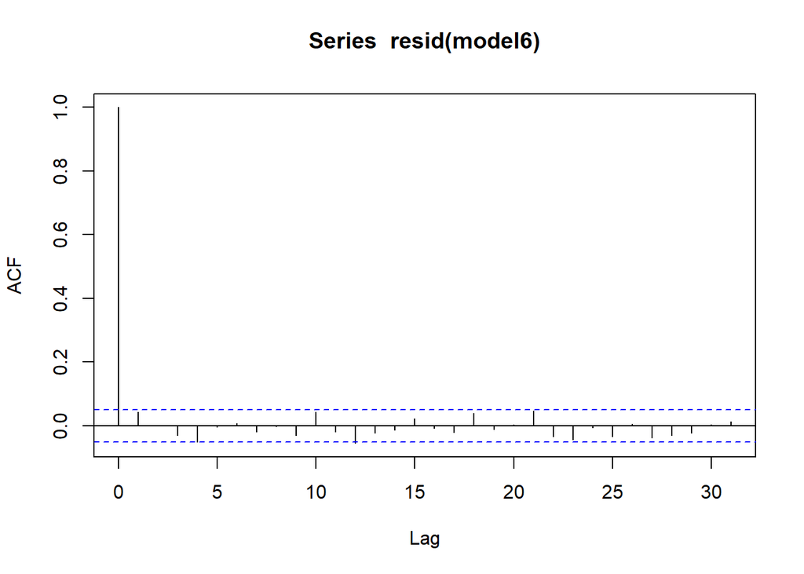

```r
acf(resid(model6))
```

```r
vif(model6)
```

```
##                condition           syllable_count     critical_word_length
##                 4.004175                 2.633518                 1.481569
## condition:syllable_count
##                 5.308693
```

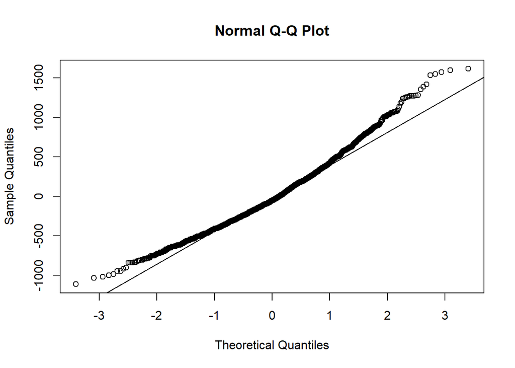

```r
qqnorm(resid(model6))
qqline(resid(model6))
```

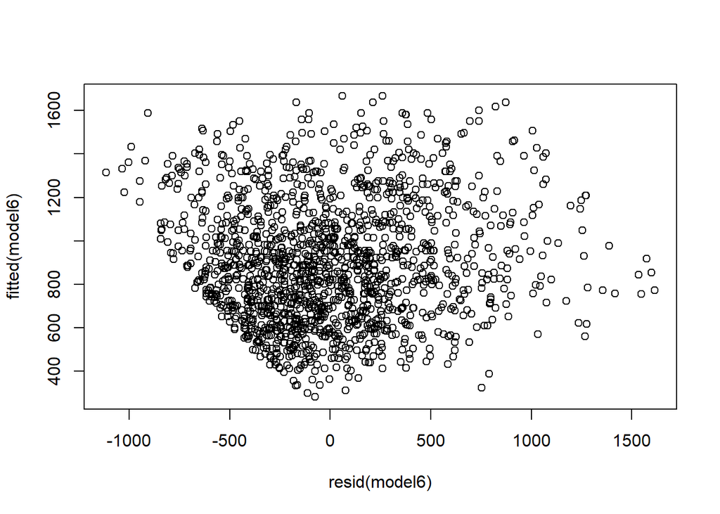

```r
plot(resid(model6), fitted(model6))
```